# Taller 5

Ariadna Sofía Contreras Abril, Angie Catalina Villate

19/10/2022

```r
suppressMessages(suppressWarnings(library(readr)))
suppressMessages(suppressWarnings(library(tidyverse)))
suppressMessages(suppressWarnings(library(tidytext)))
suppressMessages(suppressWarnings(library(magrittr)))
suppressMessages(suppressWarnings(library(gridExtra)))
suppressMessages(suppressWarnings(library(dplyr)))
suppressMessages(suppressWarnings(library(wordcloud)))
suppressMessages(suppressWarnings(library(RColorBrewer)))
suppressMessages(suppressWarnings(library(reshape2)))
suppressMessages(suppressWarnings(library(igraph)))
suppressMessages(suppressWarnings(library(ngram)))
```

## 1 Importación de los discursos

Se importan los discursos txt, asegurándose de trabajar con formato UTF-8 y que cada línea se tome como un individuo

```r
text_obama <- read_csv("Discurso_Obama.txt", col_names = FALSE, show_col_types = FALSE)
text_trump <- read_csv("Discurso_Trump.txt", col_names = FALSE, show_col_types = FALSE)
text_bush <- read_csv("discurso_bush.txt", col_names = FALSE, show_col_types = FALSE)
text_biden <- read_csv("Discurso_Biden.txt", col_names = FALSE, show_col_types = FALSE)
```

Ahora se concatenan los data frame creados para obtener una lista con cada línea como un objeto y posteriormente se vuelve cada lista un vector eliminando los nombres de estos vectores

```r
text_obama <- unlist(c(text_obama))
text_trump <- unlist(c(text_trump))
text_bush <- unlist(c(text_bush))
text_biden <- unlist(c(text_biden))

names(text_obama) <- names(text_trump) <- names(text_bush) <- names(text_biden) <- NULL
```

```r
#-------------------------------------------------------------------------------------------------- Bush
rbind(head(text_bush, n = 3), tail(text_bush, n = 3))
```

```
##      [,1]
## [1,] "President Clinton distinguished guests and my fellow citizens the peaceful transfer of authority is rare in history yet common in our country. With a simple oath we affirm old traditions and make new beginnings."
## [2,] "These questions that judge us also unite us, because Americans of every party and background, Americans by choice and by birth, are bound to one another in the cause of freedom. We have known divisions, which must be healed to move forward in great purposes - and I will strive in good faith…
##      [,2]
## [1,] "As I begin, I thank President Clinton for his service to our nation."
## [2,] "We go forward with complete confidence in the eventual triumph of freedom. Not because history runs on the wheels of inevitability; it is human choices that move events. Not because we consider ourselves a chosen nation; God moves and chooses as He wills. We have confidence because freedom …
##      [,3]
## [1,] "And I thank Vice President Gore for a contest conducted with spirit and ended with grace."
## [2,] "When the Declaration of Independence was first read in public and the Liberty Bell was sounded in celebration, a witness said, \"It rang as if it meant something.\" In our time it means something still. America, in this young century, proclaims liberty throughout all the world, and to all t…
```

```r
#-------------------------------------------------------------------------------------------------- Obama
rbind(head(text_obama, n = 3), tail(text_obama, n = 3))
```

```
##      [,1]
## [1,] "My fellow citizens: I stand here today humbled by the task before us grateful for the trust you've bestowed mindful of the sacrifices borne by our ancestors."
## [2,] "They are the words of citizens and they represent our greatest hope. You and I as citizens have the power to set this country’s course. You and I as citizens have the obligation to shape the debates of our time not only with the votes we cast but with the voices we lift in defense of our mo…
##      [,2]
## [1,] "I thank President Bush for his service to our nation as well as the generosity and cooperation he has shown throughout this transition."
## [2,] "Let us each of us now embrace with solemn duty and awesome joy what is our lasting birthright. With common effort and common purpose with passion and dedication let us answer the call of history and carry into an uncertain future that precious light of freedom."
##      [,3]
## [1,] "Forty four Americans have now taken the presidential oath. The words have been spoken during rising tides of prosperity and the still waters of peace. Yet every so often the oath is taken amidst gathering clouds and raging storms. At these moments America has carried on not simply because o…
## [2,] "Thank you. God bless you and may He forever bless these United States of America."
```

```r
#-------------------------------------------------------------------------------------------------- Trump
rbind(head(text_trump, n = 3), tail(text_trump, n = 3))
```

```
##      [,1]
## [1,] "Chief Justice Roberts President Carter President Clinton President Bush President Obama fellow Americans and people of the world thank you."
## [2,] "We stand at the birth of a new millennium ready to unlock the histories of space to free the earth from the miseries of disease and to harness the energies industries and technologies of tomorrow. A new national pride will lift our sights and heal our divisions. It's time to remember that o…
##      [,2]
## [1,] "We the citizens of America are now joined in a great national effort to rebuild our country and restore its promise for all of our people. Together we will determine the course of America and the world for many many years to come. We will face challenges. We will confront hardships but we w…
## [2,] "And whether a child is born in the urban sprawl of Detroit or the windswept plains of Nebraska they look up at the same night sky. They fill their heart with the same dreams and they are infused with the breath of life by the same almighty creator. So to all Americans in every city near and…
##      [,3]
## [1,] "Today's ceremony however has very special meaning because today we are not merely transferring power from one administration to another or from one party to another but we are transferring power from Washington D.C. and giving it back to you the people."
## [2,] "Together we will make America strong again. We will make America wealthy again. We will make America proud again. We will make America safe again. And yes together we will make America great again. Thank you. God bless you and god bless America. Thank you. God bless America."
```

```r
#-------------------------------------------------------------------------------------------------- Biden
rbind(head(text_biden, n = 3), tail(text_biden, n = 3))
```

```
##      [,1]
## [1,] "Chief Justice Roberts Vice President Harris Speaker Pelosi Leader Schumer Leader McConnell Vice President Pence distinguished guests and my fellow Americans."
## [2,] "And devoted to one another and to this country we love with all our hearts."
##      [,2]
## [1,] "This is America’s day."
## [2,] "May God bless America and may God protect our troops."
##      [,3]
## [1,] "This is democracy’s day."
## [2,] "Thank you America."
```

Se crea un objeto tibble en donde se indique el número de cada línea de los discursos

```r
# tibble en lugar de data_frame
text_bush_st <- tibble(line = 1:length(text_bush), text = text_bush)
text_obama_st <- tibble(line = 1:length(text_obama), text = text_obama)
text_trump_st <- tibble(line = 1:length(text_trump), text = text_trump)
text_biden_st <- tibble(line = 1:length(text_biden), text = text_biden)
```

```r
#----------------------------------------------------------------------------------------------------- Bush
rbind(head(text_bush_st, n = 3), tail(text_bush_st, n = 3))
```

```
## # A tibble: 6 x 2
##    line text
##   <int> <chr>
## 1     1 "President Clinton distinguished guests and my fellow citizens the peac~
## 2     2 "As I begin, I thank President Clinton for his service to our nation."
## 3     3 "And I thank Vice President Gore for a contest conducted with spirit an~
## 4    79 "These questions that judge us also unite us, because Americans of ever~
## 5    80 "We go forward with complete confidence in the eventual triumph of free~
## 6    81 "When the Declaration of Independence was first read in public and the ~
```

```r
#----------------------------------------------------------------------------------------------------- Obama
rbind(head(text_obama_st, n = 3), tail(text_obama_st, n = 3))
```

```
## # A tibble: 6 x 2
##    line text
##   <int> <chr>
## 1     1 My fellow citizens: I stand here today humbled by the task before us gr~
## 2     2 I thank President Bush for his service to our nation as well as the gen~
## 3     3 Forty four Americans have now taken the presidential oath. The words ha~
## 4    62 They are the words of citizens and they represent our greatest hope. Yo~
## 5    63 Let us each of us now embrace with solemn duty and awesome joy what is ~
## 6    64 Thank you. God bless you and may He forever bless these United States o~
```

```r
#----------------------------------------------------------------------------------------------------- Trump
rbind(head(text_trump_st, n = 3), tail(text_trump_st, n = 3))
```

```
## # A tibble: 6 x 2
##    line text
##   <int> <chr>
## 1     1 Chief Justice Roberts President Carter President Clinton President Bush~
## 2     2 We the citizens of America are now joined in a great national effort to~
## 3     3 Today's ceremony however has very special meaning because today we are ~
## 4    17 We stand at the birth of a new millennium ready to unlock the histories~
## 5    18 And whether a child is born in the urban sprawl of Detroit or the winds~
## 6    19 Together we will make America strong again. We will make America wealth~
```

```r
#----------------------------------------------------------------------------------------------------- Biden
rbind(head(text_biden_st, n = 3), tail(text_biden_st, n = 3))
```

```
## # A tibble: 6 x 2
##    line text
##   <int> <chr>
## 1     1 Chief Justice Roberts Vice President Harris Speaker Pelosi Leader Schum~
## 2     2 This is America’s day.
## 3     3 This is democracy’s day.
## 4   207 And devoted to one another and to this country we love with all our hea~
## 5   208 May God bless America and may God protect our troops.
## 6   209 Thank you America.
```

## 2 Tokenización

Se tokeniza cada línea de los discursos para poder obtener datos estructurados, es decir, que cada palabra sea una unidad de análisis

```r
# se tokeniza cada línea del discurso

#------------------------------------------------------------------------------------------------------------------------ Bush
text_bush <- text_bush_st %>%
  unnest_tokens(input = text, output = word) %>%
  filter(!is.na(word))

dim(text_bush)
```

```
## [1] 3653    2
```

```r
rbind(head(text_bush, n = 5), tail(text_bush, n = 5))
```

```
## # A tibble: 10 x 2
##     line word
##    <int> <chr>
##  1     1 president
##  2     1 clinton
##  3     1 distinguished
##  4     1 guests
##  5     1 and
##  6    81 the
##  7    81 united
##  8    81 states
##  9    81 of
## 10    81 america
```

```r
#----------------------------------------------------------------------------------------------------------- Obama
text_obama <- text_obama_st %>%
  unnest_tokens(input = text, output = word) %>%
  filter(!is.na(word))

dim(text_obama)
```

```
## [1] 4505    2
```

```r
rbind(head(text_obama, n = 5), tail(text_obama, n = 5))
```

```
## # A tibble: 10 x 2
##     line word
##    <int> <chr>
##  1     1 my
##  2     1 fellow
##  3     1 citizens
##  4     1 i
##  5     1 stand
##  6    64 these
##  7    64 united
##  8    64 states
##  9    64 of
## 10    64 america
```

```r
#--------------------------------------------------------------------------------------------------------------- Trump
text_trump <- text_trump_st %>%
  unnest_tokens(input = text, output = word) %>%
  filter(!is.na(word))

dim(text_trump)
```

```
## [1] 1454    2
```

```r
rbind(head(text_trump, n = 5), tail(text_trump, n = 5))
```

```
## # A tibble: 10 x 2
##     line word
##    <int> <chr>
##  1     1 chief
##  2     1 justice
##  3     1 roberts
##  4     1 president
##  5     1 carter
##  6    19 thank
##  7    19 you
##  8    19 god
##  9    19 bless
## 10    19 america
```

```r
#----------------------------------------------------------------------------------------------------------- Biden
text_biden <- text_biden_st %>%
  unnest_tokens(input = text, output = word) %>%
  filter(!is.na(word))

dim(text_biden)
```

```
## [1] 2377    2
```

```r
rbind(head(text_biden, n = 5), tail(text_trump, n = 5))
```

```
## # A tibble: 10 x 2
##     line word
##    <int> <chr>
##  1     1 chief
##  2     1 justice
##  3     1 roberts
##  4     1 vice
##  5     1 president
##  6    19 thank
##  7    19 you
##  8    19 god
##  9    19 bless
## 10    19 america
```

Como se puede observar la tokenización elimina signos de puntuación y convierte todas las palabras a minúsculas.

## 3 Normalización del texto

### 3.1 Eliminar números

Debido a que en los discursos no hay ningún símbolo especial ni acentos por estar en inglés, se procede a ver si hay números

```r
#Ver si hay números en los discursos

#--------------------------------------------------------------------------------------------------- Bush
text_bush %>%
  filter(grepl(pattern = '[0-9]', x = word)) %>%
  count(word, sort = TRUE)
```

```
## # A tibble: 1 x 2
##   word      n
##   <chr> <int>
## 1 225       1
```

Encontramos que solo hay un número en los discursos de Bush, el cual hace referencia a una temporalidad, y debido a que solo aparece una vez en el discurso de Bush no se considera relevante.

```r
#------------------------------------------------------------------------------------------------------- Obama
text_obama %>%
  filter(grepl(pattern = '[0-9]', x = word)) %>%
  count(word, sort = TRUE)
```

```
## # A tibble: 4 x 2
##   word      n
##   <chr> <int>
## 1 1776      1
## 2 40        1
## 3 400       1
## 4 60        1
```

De los números que se encuentran en el discruso de Obama ninguno es relevante para el análisis del discurso, 1776 es el año en el que llegaron los padres fundadores y se da a entender en el contexto de la línea, mientras que los números 40, 400 y 60 son solo años que se refieren al futuro y pasado. Además al repetirse cada número una sola vez se confirma que no son muy relevantes en el texto.

```r
#------------------------------------------------------------------------------------------------------ Trump
text_trump %>%
  filter(grepl(pattern = '[0-9]', x = word)) %>%
  count(word, sort = TRUE)
```

```
## # A tibble: 2 x 2
##   word      n
##   <chr> <int>
## 1 2017      1
## 2 20th      1
```

De los números encontrados en el discruso de Trump, ambos números se refieren al día y año de la posesión del presidente Trump, sin embargo como solo se nombran una vez en todo el texto no se considera relevante para el análisis.

```r
#------------------------------------------------------------------------------------------------ Biden
text_biden %>%
  filter(grepl(pattern = '[0-9]', x = word)) %>%
  count(word, sort = TRUE)
```

```
## # A tibble: 6 x 2
##   word       n
##   <chr>  <int>
## 1 108        1
## 2 11         1
## 3 1863       1
## 4 400        1
## 5 400000     1
## 6 9          1
```

En cuanto a los números encontrados en el discurso de Biden, hacen referencia a fechas o referencias temporales, además de una mención a las victimas mortales de la pandemia.

```r
# Eliminar números de los discursos

#----------------------------------------------------------------------------------------------------------------- Bush
text_bush %<>%
  filter(!grepl(pattern = '[0-9]', x = word))
dim(text_bush)
```

```
## [1] 3652    2
```

```r
#------------------------------------------------------------------------------------------------------------------ Obama
text_obama %<>%
  filter(!grepl(pattern = '[0-9]', x = word))
dim(text_obama)
```

```
## [1] 4501    2
```

```r
#------------------------------------------------------------------------------------------------------------------ Trump
text_trump %<>%
  filter(!grepl(pattern = '[0-9]', x = word))
dim(text_trump)
```

```
## [1] 1452    2
```

```r
#------------------------------------------------------------------------------------------------------------------ Biden
text_biden %<>%
  filter(!grepl(pattern = '[0-9]', x = word))
dim(text_biden)
```

```
## [1] 2371    2
```

```r
##### Frecuencia de los tokens
cbind(
text_bush %>%
  count(word, sort = TRUE)%>%
  rename(word_Bush=word, n_Bush=n) %>%
  head(n = 10),

text_obama %>%
  count(word, sort = TRUE)%>%
  rename(word_Obama=word, n_Obama=n) %>%
  head(n = 10),

text_trump %>%
  count(word, sort = TRUE) %>%
  rename(word_Trump=word, n_Trump=n) %>%
  head(n = 10),

text_biden %>%
  count(word, sort = TRUE)%>%
  rename(word_Biden=word, n_Biden=n) %>%
  head(n = 10)
)
```

```
##    word_Bush n_Bush word_Obama n_Obama word_Trump n_Trump word_Biden n_Biden
## 1        the    194        the     240        and      76        the     101
## 2        and    190        and     200        the      71        and      96
## 3         of    173         of     151         of      48         we      88
## 4        our    100        our     143        our      47         of      77
## 5         we     84         to     137         we      47         to      65
## 6         to     83         we     127       will      42          a      47
## 7         in     82       that     105         to      37         in      44
## 8          a     72          a      83         is      20        our      43
## 9         is     61         is      61    america      19       this      39
## 10      that     46        for      51        for      15        for      33
```

Como se puede ver en los cuatro discursos las palabras con mayor frecuencia son aquellas que no tienen ningún peso en el análisis, también llamadas stop words, por lo que se eliminan de los discursos.

### 3.2 Stop words

Ahora se ven las stop words a utilizar

```r
data(stop_words)
dim(stop_words)
```

```
## [1] 1149    2
```

```r
table(stop_words$lexicon)
```

```
##
##     onix    SMART snowball
##      404      571      174
```

Se utilizan los tres diccionarios que vienen con la librería tidytext, onix, SMART y snowball, donde cada uno tiene 404, 571 y 174 palabras respectivamente.

Ahora se remueven las palabras de los diccionarios mencionados anteriormente de los discuros

```r
##### número de tokens por presidente
data.frame("Presidente"=c("Bush", "Obama", "Trump", "Biden"), "Num_tokens"=c(dim(text_bush)[1], dim(text_obama)[1], dim(text_trump)[1], dim(text_biden)[1]))
```

```
##   Presidente Num_tokens
## 1       Bush       1424
## 2      Obama       1713
## 3      Trump        537
## 4      Biden        817
```

Se eliminaron 2229 palabras de los discursos de Bush, 2792 palabras de los discursos de Obama, 917 del discurso de Trump y 1560 del discurso de Biden.

Ahora se ve la frecuencia de los tokens de cada discurso

```r
##### Frecuencia de los tokens por discurso
cbind(
text_bush %>%
  count(word, sort = TRUE)%>%
  rename(word_Bush=word, n_Bush=n) %>%
  head(n = 10),

text_obama %>%
  count(word, sort = TRUE)%>%
  rename(word_Obama=word, n_Obama=n) %>%
  head(n = 10),

text_trump %>%
  count(word, sort = TRUE) %>%
  rename(word_Trump=word, n_Trump=n) %>%
  head(n = 10),

text_biden %>%
  count(word, sort = TRUE)%>%
  rename(word_Biden=word, n_Biden=n) %>%
  head(n = 10)
)
```

```
##    word_Bush n_Bush word_Obama n_Obama word_Trump n_Trump word_Biden n_Biden
## 1    freedom     30     nation      18    america      19    america      18
## 2    america     20     people      18   american      11     nation      12
## 3    country     17       time      16     people      10  democracy      10
## 4     nation     17    america      14    country       9   american       9
## 5    liberty     16     common       9     nation       6  americans       9
## 6   citizens     15    freedom       9      world       6     people       9
## 7  americans     13 generation       9     dreams       5      story       9
## 8  america's     11        god       9  president       5      unity       8
## 9       time     11    journey       9  protected       5      world       8
## 10     world     11      world       9  americans       4    history       7
```

Como se puede observar hay palabras con el mismo sufijo o que se pueden considerar como sinónimos, por lo tanto para un mejor análisis esas palabras se agrupan en una sola.

### 3.3 Sufijos o sinónimos

```r
#------------------------------------------------------------------------------------------------------------ Bush
text_bush%<>%
  mutate(word=case_when(word=="country"~"america",
                        word=="america's"~"america",
                        word=="nation"~"america",
                        word=="american"~"americans",
                        word=="citizens"~"americans",
                        word=="liberty"~"freedom",
                        TRUE~word))

#------------------------------------------------------------------------------------------------------------ Obama
text_obama%<>%
  mutate(word=case_when(word=="country"~"america",
                        word=="nation"~"america",
                        word=="american"~"americans",
                        word=="citizens"~"americans",
                        word=="liberty"~"freedom",
                        TRUE~word))

#------------------------------------------------------------------------------------------------------------ Trump
text_trump%<>%
  mutate(word=case_when(word=="country"~"america",
                        word=="nation"~"america",
                        word=="american"~"americans",
                        word=="citizens"~"americans",
                        TRUE~word))

#------------------------------------------------------------------------------------------------------------ Biden
text_biden%<>%
  mutate(word=case_when(word=="country"~"america",
                        word=="nation"~"america",
                        word=="american"~"americans",
                        word=="citizens"~"americans",
                        word=="liberty"~"freedom",
                        TRUE~word))
```

```r
##### Frecuencia de los tokens por discurso
cbind(
  #----------------------------------------------------------------------------------------------------- Bush
text_bush %>%
  count(word, sort = TRUE)%>%
  rename(word_Bush=word, n_Bush=n) %>%
  head(n = 30),

#----------------------------------------------------------------------------------------------------- Obama
text_obama %>%
  count(word, sort = TRUE)%>%
  rename(word_Obama=word, n_Obama=n) %>%
  head(n = 30),

#----------------------------------------------------------------------------------------------------- Trump
text_trump %>%
  count(word, sort = TRUE) %>%
  rename(word_Trump=word, n_Trump=n) %>%
  head(n = 30),

#----------------------------------------------------------------------------------------------------- Biden
text_biden %>%
  count(word, sort = TRUE)%>%
  rename(word_Biden=word, n_Biden=n) %>%
  head(n = 30)
)
```

```
##     word_Bush n_Bush word_Obama n_Obama word_Trump n_Trump word_Biden n_Biden
## 1     america     65    america      40    america      34    america      34
## 2     freedom     46  americans      22  americans      19  americans      19
## 3   americans     34     people      18     people      10  democracy      10
## 4        time     11    freedom      16      world       6     people       9
## 5       world     11       time      16     dreams       5      story       9
## 6     history     10     common       9  president       5      unity       8
## 7     justice      9 generation       9  protected       5      world       8
## 8       story      9        god       9      bring       4    history       7
## 9   character      8    journey       9        day       4  president       7
## 10        day      8      world       9        god       4        war       7
## 11       free      8      words       8      heart       4        day       6
## 12       hope      8      equal       7       jobs       4       days       6
## 13    courage      7     future       7      power       4      stand       6
## 14 government      7 government       7     wealth       4   children       5
```

[output cut: 16 more lines]

## 4 Visualizaciones

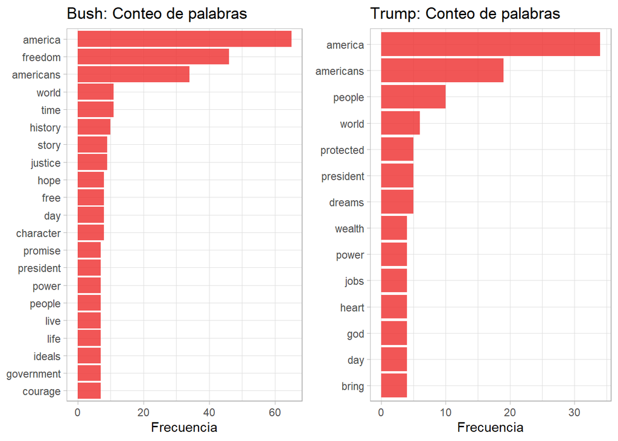

```r
#------------------------------------------------------------------------------------------------ Bush
text_bush %>%
  count(word, sort = TRUE) %>%
  filter(n > 6) %>%
  mutate(word = reorder(word, n)) %>%
  ggplot(aes(x = word, y = n)) +
    theme_light() +
    geom_col(fill = 'firebrick2', alpha = 0.8) +
    xlab(NULL) +
    ylab("Frecuencia") +
    coord_flip() +
    ggtitle(label = 'Bush: Conteo de palabras') -> p1

#------------------------------------------------------------------------------------------------- Obama
text_obama %>%
  count(word, sort = TRUE) %>%
  filter(n > 6) %>%
  mutate(word = reorder(word, n)) %>%
  ggplot(aes(x = word, y = n)) +
    theme_light() +
    geom_col(fill = 'dodgerblue4', alpha = 0.8) +
    xlab(NULL) +
    ylab("Frecuencia") +
    coord_flip() +
    ggtitle(label = 'Obama: Conteo de palabras') -> p2

# ------------------------------------------------------------------------------------------------ Trump
text_trump %>%
  count(word, sort = TRUE) %>%
  filter(n > 3) %>%
  mutate(word = reorder(word, n)) %>%
  ggplot(aes(x = word, y = n)) +
    theme_light() +
    geom_col(fill = 'firebrick2', alpha = 0.8) +
    xlab(NULL) +
    ylab("Frecuencia") +
    coord_flip() +
    ggtitle(label = 'Trump: Conteo de palabras') -> p3

#------------------------------------------------------------------------------------------------- Biden
text_biden %>%
  count(word, sort = TRUE) %>%
  filter(n > 4) %>%
  mutate(word = reorder(word, n)) %>%
  ggplot(aes(x = word, y = n)) +
    theme_light() +
    geom_col(fill = 'dodgerblue4', alpha = 0.8) +
    xlab(NULL) +
    ylab("Frecuencia") +
    coord_flip() +
    ggtitle(label = 'Biden: Conteo de palabras') -> p4

grid.arrange(p1, p3, ncol = 2)
```

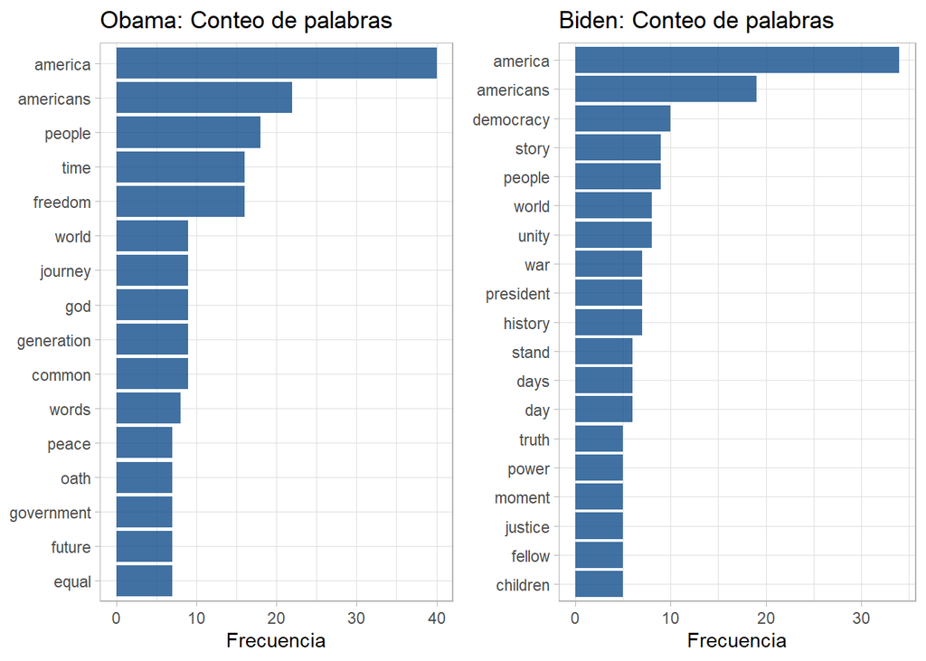

```r
grid.arrange(p2, p4, ncol = 2)
```

Como se puede ver de los gráficos de barras, en todos los discursos se tienen varias palabras en común, siendo las principales, america y americans. Lo cual indica que los discursos se centran más en el país y sus ciudadanos, encontramos otras palabras comunes como people o world, sin embargo el resto de palabras parecen diferir un poco. Esto debido a que las palabras de los discursos de Bush estan encaminadas a la justicia y a temas relacionados con contextos historicos, por otro lado, las de Obama parecen estar más encaminadas hacia la libertad, paz e igualdad en esa generación, el discurso de Trump indica que trata más sobre proteger el sueño americano, el poder y la riqueza. Finalmente, Biden parece mostrarse mas neutral a pesar de tener war entre sus palabras principales,esto debido a que otras palabras no son solo enfocadas en el patriotismo estadounidense y pueden verse entre las principales de su discurso. Esto mismo se puede observar en las siguientes nubes de palabras.

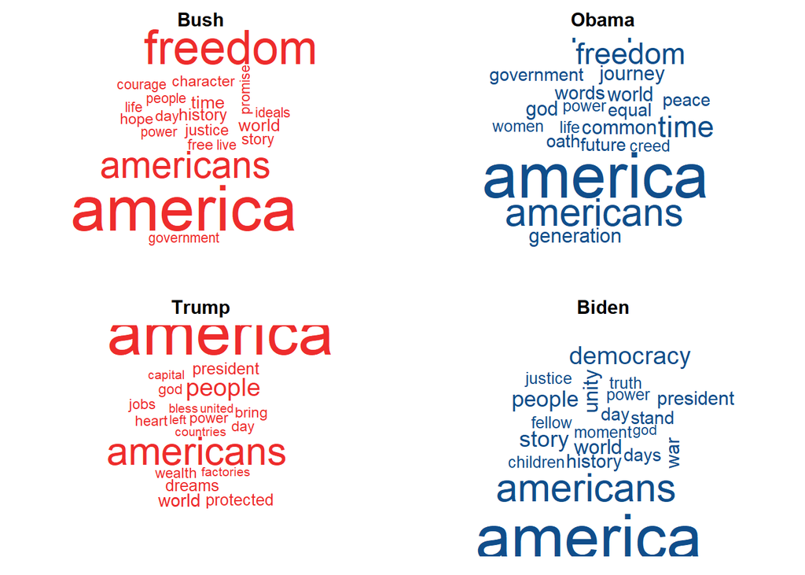

```r
par(mfrow = c(2,2), mar = c(1,1,2,1), mgp = c(1,1,1))

# ---------------------------------------------------------------------------------------------- Bush
set.seed(123)
text_bush%>%
  count(word, sort = TRUE) %>%
  with(wordcloud(words = word, freq = n, max.words = 20, colors = 'firebrick2'))
title(main = "Bush")

# ----------------------------------------------------------------------------------------------- Obama
set.seed(12)
text_obama %>%
  count(word, sort = TRUE) %>%
  with(wordcloud(words = word, freq = n, max.words = 20, colors = 'dodgerblue4'))
title(main = "Obama")

# ----------------------------------------------------------------------------------------------- Trump
set.seed(123)
text_trump %>%
  count(word, sort = TRUE) %>%
  with(wordcloud(words = word, freq = n, max.words = 20, colors = 'firebrick2'))
title(main = "Trump")

# ------------------------------------------------------------------------------------------------ Biden
set.seed(12)
text_biden %>%
  count(word, sort = TRUE) %>%
  with(wordcloud(words = word, freq = n, max.words = 20, colors = 'dodgerblue4'))
title(main = "Biden")
```

## 5 Frecuencias y correlaciones

### 5.1 Frecuencias de palabras en cada discurso

```r
##### frecuencias relativas de la palabras
frec<-bind_rows(mutate(.data = text_bush, author = "Bush"),
                mutate(.data = text_obama, author = "Obama"),
                mutate(.data = text_trump, author = "Trump"),
                mutate(.data = text_biden, author = "Biden")) %>%
  count(author, word) %>%
  group_by(author) %>%
  mutate(proportion = n/sum(n)) %>%
  select(-n) %>%
  spread(author, proportion, fill = 0) %>%
  select(word, Bush, Obama, Trump, Biden)

# total de tokens entre los discursos de los 4 ex-presidentes
dim(frec)
```

```
## [1] 1930    5
```

Uniendo los tokens de los discursos de los cuatro ex-presidentes, se ve que hay 1930 palabras entre los discursos

```r
head(frec, n = 10)
```

```
## # A tibble: 10 x 5
##    word            Bush    Obama   Trump   Biden
##    <chr>          <dbl>    <dbl>   <dbl>   <dbl>
##  1 abandon     0.00140  0        0       0
##  2 abandoned   0        0.000584 0       0
##  3 abandonment 0.000702 0        0       0
##  4 ability     0        0.000584 0       0
##  5 abraham     0.000702 0        0       0.00122
##  6 abroad      0        0.000584 0       0
##  7 absolutism  0        0.000584 0       0
##  8 abuse       0.000702 0        0       0
##  9 accept      0.00211  0.000584 0.00186 0
## 10 accepted    0.00140  0        0       0
```

Ahora se analizarán las palabras que tuvieron en común los presidentes por partido, republicano y demócrata.

```r
# --------------------------------------------------------------------------------------------------- Republicanos
frec_comun_repu<-frec %>%
  filter(Bush !=0, Trump != 0) %>%
  arrange(desc(Bush), desc(Trump)) %>% select(word, Bush, Trump)

dim(frec_comun_repu)
```

```
## [1] 126   3
```

```r
###### proporción de palabras en común
dim(frec_comun_repu)[1]/dim(frec)[1]
```

```
## [1] 0.06528497
```

De las 1930 palabras solo 126 se usaron en ambos discursos de los presidentes republicanos, es decir los discursos de Bush y Trump comparten el $6.53\%$ del total de palabras encontradas en los cuatro discursos.

```r
head(frec_comun_repu, n = 10)
```

```
## # A tibble: 10 x 3
##    word         Bush   Trump
##    <chr>       <dbl>   <dbl>
##  1 america   0.0456  0.0633
##  2 americans 0.0239  0.0354
##  3 world     0.00772 0.0112
##  4 time      0.00772 0.00372
##  5 justice   0.00632 0.00186
##  6 day       0.00562 0.00745
##  7 free      0.00562 0.00186
##  8 people    0.00492 0.0186
##  9 president 0.00492 0.00931
## 10 power     0.00492 0.00745
```

```r
# --------------------------------------------------------------------------------------------- Demócratas
frec_comun_dem<-frec %>%
  filter(Obama !=0, Biden != 0) %>%
  arrange(desc(Obama), desc(Biden)) %>% select(word, Obama, Biden)

dim(frec_comun_dem)
```

```
## [1] 216   3
```

```r
###### proporción de palabras en común
dim(frec_comun_dem)[1]/dim(frec)[1]
```

```
## [1] 0.1119171
```

De las 1930 palabras solo 216 se usaron en ambos discursos de los presidentes demócratas, es decir los discursos de Obama y Biden comparten el $11.19\%$ del total de palabras encontradas en los cuatro discursos.

```r
head(frec_comun_dem, n = 10)
```

```
## # A tibble: 10 x 3
##    word        Obama   Biden
##    <chr>       <dbl>   <dbl>
##  1 america   0.0234  0.0416
##  2 americans 0.0128  0.0233
##  3 people    0.0105  0.0110
##  4 time      0.00934 0.00490
##  5 freedom   0.00934 0.00245
##  6 world     0.00525 0.00979
##  7 god       0.00525 0.00490
##  8 common    0.00525 0.00367
##  9 words     0.00467 0.00122
## 10 peace     0.00409 0.00490
```

A continuación se analizan las palabras que tuvieron en común los discursos demócratas con los republicanos.

```r
##### frecuencias relativas de la palabras por partido
frec_part<- frec %>%
            mutate(democratas= Obama+Biden, republicanos = Bush+Trump) %>%
            filter(democratas !=0, republicanos!= 0) %>%
            arrange(desc(democratas), desc(republicanos)) %>%
            select(word, democratas, republicanos)

dim(frec_part)
```

```
## [1] 477   3
```

```r
###### proporción de palabras en común entre partidos
dim(frec_part)[1]/dim(frec)[1]
```

```
## [1] 0.2471503
```

Entre los discursos demócratas y republicanos se comparten 477 palabras, de las 1930 de la totalidad de los discursos trabajados, esto equivale al $24.72\%$ del total de palabras encontradas en los cuatro discursos.

```r
head(frec_part, n = 10)
```

```
## # A tibble: 10 x 3
##    word      democratas republicanos
##    <chr>          <dbl>        <dbl>
##  1 america       0.0650     0.109
##  2 americans     0.0361     0.0593
##  3 people        0.0215     0.0235
##  4 world         0.0150     0.0189
##  5 time          0.0142     0.0114
##  6 democracy     0.0134     0.00211
##  7 freedom       0.0118     0.0323
##  8 history       0.0115     0.00702
##  9 war           0.0115     0.000702
## 10 story         0.0110     0.00632
```

### 5.2 Correlación entre las frecuencias de las palabras de los discursos

```r
suppressMessages(suppressWarnings(library(car)))

##### Pruebas de normalidad de las frecuencias
Normalidad <- c(shapiro.test(frec$Bush)$p.value,
shapiro.test(frec$Obama)$p.value,
shapiro.test(frec$Trump)$p.value,
shapiro.test(frec$Biden)$p.value)

names(Normalidad) <- c("Bush", "Obama", "Trump", "Biden")

Normalidad
```

```
##         Bush        Obama        Trump        Biden
## 1.506338e-66 4.180239e-61 3.581862e-67 1.277293e-64
```

```r
##### al no haber normalidad en las frecuencias relativas de ningún discruso se usa la prueba de Levene para ver si hay homocedasticidad
PV<-matrix(NA, 4, 4)

PV[1,2]<- (leveneTest(c(frec$Bush[frec$Bush!=0], frec$Obama[frec$Obama!=0]),
           c(rep("Bush",809),rep("Obama",1066)))$`Pr(>F)`)[1]
PV[1,3]<-(leveneTest(c(frec$Bush[frec$Bush!=0], frec$Trump[frec$Trump!=0]),
           c(rep("Bush",809),rep("Trump",365)))$`Pr(>F)`)[1]
PV[1,4]<-(leveneTest(c(frec$Bush[frec$Bush!=0], frec$Biden[frec$Biden!=0]),
           c(rep("Bush",809),rep("Biden",509)))$`Pr(>F)`)[1]
PV[2,3]<-(leveneTest(c(frec$Obama[frec$Obama!=0], frec$Trump[frec$Trump!=0]),
           c(rep("Obama",1066),rep("Trump",365)))$`Pr(>F)`)[1]
PV[2,4]<-(leveneTest(c(frec$Obama[frec$Obama!=0], frec$Biden[frec$Biden!=0]),
           c(rep("Obama",1066),rep("Biden",509)))$`Pr(>F)`)[1]
PV[3,4]<-(leveneTest(c(frec$Trump[frec$Trump!=0], frec$Biden[frec$Biden!=0]),
           c(rep("Trump",365),rep("Biden",509)))$`Pr(>F)`)[1]

colnames(PV)<-rownames(PV)<- c("Bush", "Obama", "Trump", "Biden")

round(PV,4)
```

```
##       Bush  Obama  Trump  Biden
## Bush    NA 0.0252 0.0611 0.1214
## Obama   NA     NA 0.0001 0.0000
## Trump   NA     NA     NA 0.5312
## Biden   NA     NA     NA     NA
```

Debido a que no hay normalidad en las frecuencias de ningún candidato, como se puede observar en el vecor con los p-valores de la prueba de Shapiro para cada presidente, y hay homocedasticidad solo entre Bush y Trump, Bush y Biden y entre Trump y Biden, supuestos que son necesarios para realizar el coeficiente de correlación de Pearson. Se calculan los coeficientes de correlación solo entre los presidentes que presentaron homocedasticidad, vale aclarar que estos valores no van a ser confiables para hacer conclusiones, sin embargo pueden considerarse como ideas preliminares para el análisis.

```r
##### número de palabras en común
com_BB <- dim(frec %>%
  filter(Bush !=0, Biden != 0) %>%
  select(word, Bush, Biden))[1]

com_TB <- dim(frec %>%
  filter(Trump !=0, Biden != 0) %>%
  select(word, Trump, Biden))[1]

##### correlacion de las frecuencias
Corr<-matrix(NA, 3, 3)

Corr[1,2]<-cor.test(x = c(frec$Bush[frec$Bush!=0], rep(0, 239)), y = c(frec$Trump[frec$Trump!=0], rep(0, 683)))$estimate
Corr[1,3]<-cor.test(x = c(frec$Bush[frec$Bush!=0], rep(0, 509-com_BB)), y = c(frec$Biden[frec$Biden!=0], rep(0, 809-com_BB)))$estimate
Corr[2,3]<-cor.test(x = c(frec$Trump[frec$Trump!=0], rep(0, 509-com_TB)), y = c(frec$Biden[frec$Biden!=0],
                                                                                rep(0,365-com_TB)))$estimate

rownames(Corr) <- colnames(Corr) <- c("Bush", "Trump", "Biden")

round(Corr,3)
```

```
##       Bush Trump Biden
## Bush    NA 0.066 0.104
## Trump   NA    NA 0.356
## Biden   NA    NA    NA
```

Las correlaciones calculadas podrían indicar que entre las frecuencias de las palabras de los discursos de los presidentes mencionados, parece no haber correlación lineal.

## 6 Análisis de sentimiento

Primero se escoge el diccionario a utilizar en el análisis de sentimientos

```r
table(AFINN$sentiment)
```

```
##
## negative positive
##     1586      891
```

```r
table(sentiments$sentiment)
```

```
##
## negative positive
##     4781     2005
```

```r
table(NRC$sentiment)
```

```
##
## negative positive
##    11927    10919
```

Debido a que el diccionario NRC es el que tiene una mayor cantidad de palabras tanto positivas como negativas, es con este diccionario con el que se realiza el siguiente análisis

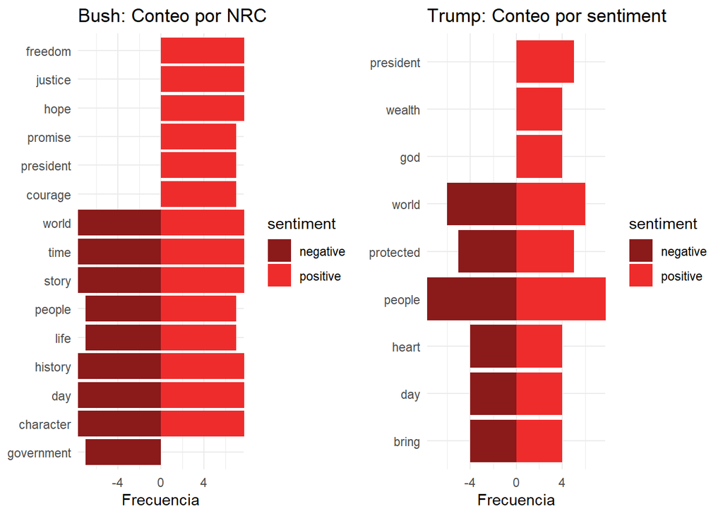

```r
#-------------------------------------------------------------------- Bush
text_bush %>%
  inner_join(NRC) %>%
  count(word, sentiment, sort = TRUE) %>%
  filter(n > 6) %>%
  mutate(n = ifelse(sentiment == "negative", -n, n)) %>%
  mutate(word = reorder(word, n)) %>%
  ggplot(aes(word, n, fill = sentiment)) +
    geom_col() +
    scale_fill_manual(values = c("firebrick4", "firebrick2")) +
    coord_flip(ylim = c(-7,7)) +
    labs(y = "Frecuencia",
         x = NULL,
         title = "Bush: Conteo por NRC") +
    theme_minimal() -> p1
#-------------------------------------------------------------------- Obama
text_obama %>%
  inner_join(NRC) %>%
  count(word, sentiment, sort = TRUE) %>%
  filter(n > 6) %>%
  mutate(n = ifelse(sentiment == "negative", -n, n)) %>%
  mutate(word = reorder(word, n)) %>%
  ggplot(aes(word, n, fill = sentiment)) +
    geom_col() +
    scale_fill_manual(values = c("dodgerblue4", "deepskyblue")) +
    coord_flip(ylim = c(-7,7)) +
    labs(y = "Frecuencia",
         x = NULL,
         title = "Obama: Conteo por NRC") +
    theme_minimal() -> p2
#-------------------------------------------------------------------- Trump
text_trump %>%
  inner_join(NRC) %>%
  count(word, sentiment, sort = TRUE) %>%
  filter(n > 3) %>%
  mutate(n = ifelse(sentiment == "negative", -n, n)) %>%
  mutate(word = reorder(word, n)) %>%
  ggplot(aes(word, n, fill = sentiment)) +
    geom_col() +
    scale_fill_manual(values = c("firebrick4", "firebrick2")) +
    coord_flip(ylim = c(-7,7)) +
    labs(y = "Frecuencia",
         x = NULL,
         title = "Trump: Conteo por sentiment") +
    theme_minimal() -> p3
#-------------------------------------------------------------------- Biden
text_biden %>%
  inner_join(NRC) %>%
  count(word, sentiment, sort = TRUE) %>%
  filter(n > 5) %>%
  mutate(n = ifelse(sentiment == "negative", -n, n)) %>%
  mutate(word = reorder(word, n)) %>%
  ggplot(aes(word, n, fill = sentiment)) +
    geom_col() +
    scale_fill_manual(values = c("dodgerblue4", "deepskyblue")) +
    coord_flip(ylim = c(-7,7)) +
    labs(y = "Frecuencia",
         x = NULL,
         title = "Biden: Conteo por NRC") +
    theme_minimal() -> p4
grid.arrange(p1, p3, ncol = 2)
```

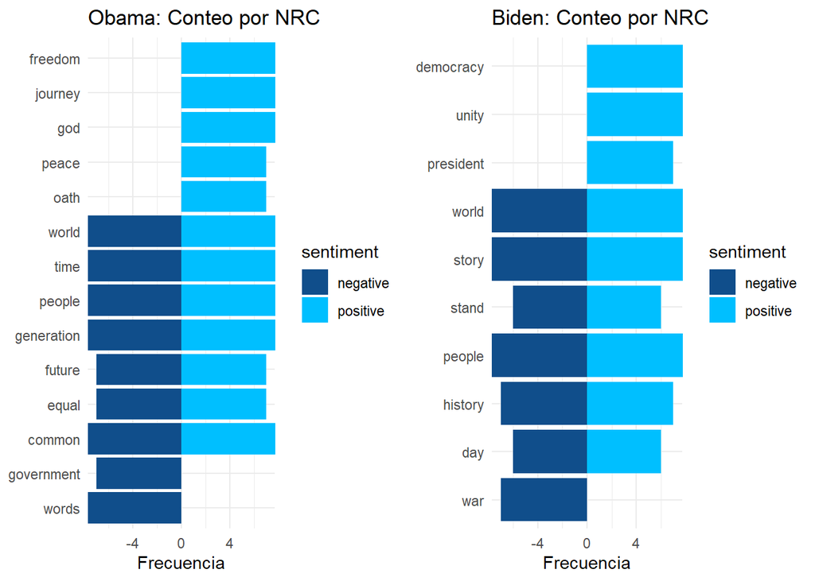

```r
grid.arrange(p2, p4, ncol = 2)
```

En los gráficos de barras las palabras con frecuencias tanto positivas como negativas se consideran como palabras neutras.De las principales palabras en cada discurso, se observa que Bush y Obama son los presidentes con mayor número de palabras tanto positivas como negativas en sus discursos, esto se puede deber al hecho de que rigieron durante dos periodos presidenciales cada uno, por lo tanto, se tomaron sus dos discursos como uno solo, lo cual implica que se tienen mayor cantidad de palabras para analizar. Además, un aspecto a resaltar es el hecho de que palabras del mismo contexto como lo son government y president tienen asociados sentimientos opuestos.

Por otro lado, se observa que los discursos entre presidentes del mismo partido no parecen seguir una misma temática a pesar de tener ideales políticos similares.

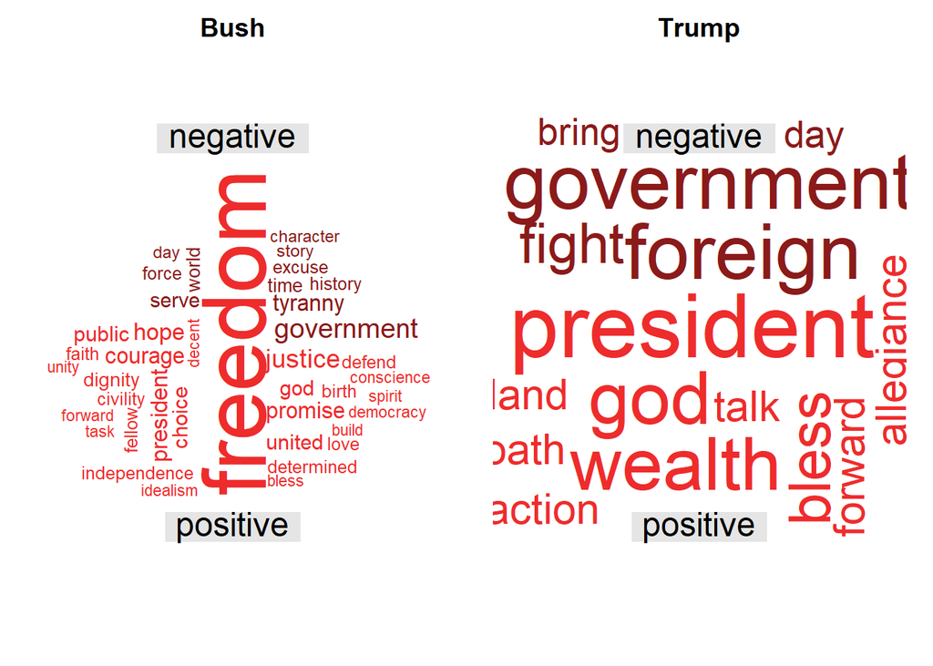

```r
par(mfrow = c(1,2), mar = c(1,1,2,1), mgp = c(1,1,1))

# ------------------------------------------------------------------------------ Bush
set.seed(123)
text_bush %>%
  inner_join(NRC) %>%
  count(word, sentiment, sort = TRUE) %>%
  acast(word ~ sentiment, value.var = "n", fill = 0) %>%
  comparison.cloud(colors = c("firebrick4", "firebrick2"),
                   max.words = 40, title.size = 1.5)
title(main = "Bush")

# ------------------------------------------------------------------------------ Trump
set.seed(12)
text_trump %>%
  inner_join(NRC) %>%
  count(word, sentiment, sort = TRUE) %>%
  acast(word ~ sentiment, value.var = "n", fill = 0) %>%
  comparison.cloud(colors = c("firebrick4", "firebrick2"),
                   max.words = 40, title.size = 1.5)
title(main = "Trump")
```

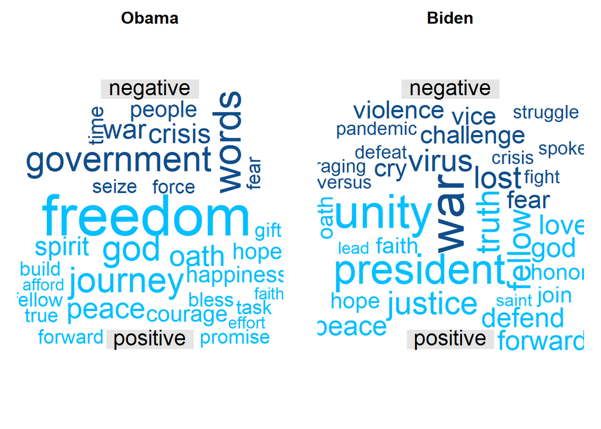

```r
par(mfrow = c(1,2), mar = c(1,1,2,1), mgp = c(1,1,1))

# ------------------------------------------------------------------------------ Obama
set.seed(12)
text_obama %>%
  inner_join(NRC) %>%
  count(word, sentiment, sort = TRUE) %>%
  acast(word ~ sentiment, value.var = "n", fill = 0) %>%
  comparison.cloud(colors = c("dodgerblue4", "deepskyblue"),
                   max.words = 40, title.size = 1.5)
title(main = "Obama")


# ------------------------------------------------------------------------------ Biden
set.seed(12)
text_biden %>%
  inner_join(NRC) %>%
  count(word, sentiment, sort = TRUE) %>%
  acast(word ~ sentiment, value.var = "n", fill = 0) %>%
  comparison.cloud(colors = c("dodgerblue4", "deepskyblue"),
                   max.words = 40, title.size = 1.5)
title(main = "Biden")
```

## 7 Bigramas

A continuación se realiza el análisis por parejas de palabras, esto para profundizar en la intención del discurso e identificar palabras compuestas.

```r
text_bush_bi <- text_bush_st %>%
  unnest_tokens(tbl = ., input = text, output = bigram, token = "ngrams", n = 2) %>%
  filter(!is.na(bigram))

text_obama_bi <- text_obama_st %>%
  unnest_tokens(tbl = ., input = text, output = bigram, token = "ngrams", n = 2) %>%
  filter(!is.na(bigram))

text_trump_bi <- text_trump_st %>%
  unnest_tokens(tbl = ., input = text, output = bigram, token = "ngrams", n = 2) %>%
  filter(!is.na(bigram))

text_biden_bi <- text_biden_st %>%
  unnest_tokens(tbl = ., input = text, output = bigram, token = "ngrams", n = 2) %>%
  filter(!is.na(bigram))

data.frame("Presidente"=c("Bush", "Obama", "Trump", "Biden"), "Num_tokens"=c(dim(text_bush_bi)[1], dim(text_obama_bi)[1], dim(text_trump_bi)[1], dim(text_biden_bi)[1]))
```

```
##   Presidente Num_tokens
## 1       Bush       3572
## 2      Obama       4441
## 3      Trump       1435
## 4      Biden       2168
```

```r
cbind(
head(text_bush_bi, n = 10) %>% rename(line_Bush=line, bigram_Bush=bigram),
head(text_obama_bi, n = 10) %>% rename(line_Obama=line, bigram_Obama=bigram),
head(text_trump_bi, n = 10) %>% rename(line_Trump=line, bigram_Trump=bigram),
head(text_biden_bi, n = 10) %>% rename(line_Biden=line, bigram_Biden=bigram)
)
```

```
##    line_Bush           bigram_Bush line_Obama    bigram_Obama line_Trump
## 1          1     president clinton          1       my fellow          1
## 2          1 clinton distinguished          1 fellow citizens          1
## 3          1  distinguished guests          1      citizens i          1
## 4          1            guests and          1         i stand          1
## 5          1                and my          1      stand here          1
## 6          1             my fellow          1      here today          1
## 7          1       fellow citizens          1   today humbled          1
## 8          1          citizens the          1      humbled by          1
## 9          1          the peaceful          1          by the          1
## 10         1     peaceful transfer          1        the task          1
##         bigram_Trump line_Biden     bigram_Biden
## 1      chief justice          1    chief justice
## 2    justice roberts          1  justice roberts
## 3  roberts president          1     roberts vice
## 4   president carter          1   vice president
## 5   carter president          1 president harris
## 6  president clinton          1   harris speaker
## 7  clinton president          1   speaker pelosi
## 8     president bush          1    pelosi leader
## 9     bush president          1   leader schumer
## 10   president obama          1   schumer leader
```

```r
cbind(text_bush_bi %>%
  count(bigram, sort = TRUE) %>%
  head(n = 10) %>%
  rename(bigram_Bush=bigram, n_Bush=n),

text_obama_bi %>%
  count(bigram, sort = TRUE) %>%
  head(n = 10) %>%
  rename(bigram_Obama=bigram, n_Obama=n),

text_trump_bi %>%
  count(bigram, sort = TRUE) %>%
  head(n = 10) %>%
  rename(bigram_Trump=bigram, n_Trump=n),

text_biden_bi %>%
  count(bigram, sort = TRUE) %>%
  head(n = 10) %>%
  rename(bigram_Biden=bigram, n_Biden=n))
```

```
##    bigram_Bush n_Bush bigram_Obama n_Obama bigram_Trump n_Trump bigram_Biden
## 1       of our     25       of our      30      we will      26       we can
## 2      we will     23       to the      20       of our      10      we will
## 3       in our     17      we will      18  our country       8        of us
## 4       in the     15       and we      12       we are       7       in the
## 5       is the     15      we must      12      will be       7       of our
## 6       of the     15      and the      11     the same       6      we have
## 7      and the     14       we are      11      and the       5      we must
## 8   of freedom     14      for the      10       at the       5       and we
## 9  our country     14       in the      10 make america       5       i will
## 10     we have     13       on the      10   of america       5      much to
##    n_Biden
## 1       15
## 2       13
## 3       10
## 4        9
## 5        9
## 6        9
## 7        9
## 8        8
## 9        7
## 10       7
```

Se normalizan los tokens de cada bigrama

```r
##### Normalización

#--------------------------------------------------------------------------------------------- Bush
text_bush_bi %>%
  separate(bigram, c("word1", "word2"), sep = " ") %>%
  filter(!grepl(pattern = '[0-9]', x = word1)) %>%        # se elmininan los números
  filter(!grepl(pattern = '[0-9]', x = word2)) %>%
  filter(!word1 %in% stop_words$word) %>%                 # se eliminan las stop words
  filter(!word2 %in% stop_words$word) %>%
  filter(!is.na(word1)) %>%                               # se eliminan tokens NA
  filter(!is.na(word2)) %>%
  count(word1, word2, sort = TRUE) %>%                    # conteo por bigramas
  rename(weight = n) -> text_bush_bi_counts


#--------------------------------------------------------------------------------------------- Obama
text_obama_bi %>%
  separate(bigram, c("word1", "word2"), sep = " ") %>%
  filter(!grepl(pattern = '[0-9]', x = word1)) %>%        # se elmininan los números
  filter(!grepl(pattern = '[0-9]', x = word2)) %>%
  filter(!word1 %in% stop_words$word) %>%                 # se eliminan las stop words
  filter(!word2 %in% stop_words$word) %>%
  filter(!is.na(word1)) %>%                               # se eliminan tokens NA
  filter(!is.na(word2)) %>%
  count(word1, word2, sort = TRUE) %>%                    # conteo por bigramas
  rename(weight = n) -> text_obama_bi_counts

#--------------------------------------------------------------------------------------------- Trump
text_trump_bi %>%
  separate(bigram, c("word1", "word2"), sep = " ") %>%
  filter(!grepl(pattern = '[0-9]', x = word1)) %>%        # se elmininan los números
  filter(!grepl(pattern = '[0-9]', x = word2)) %>%
  filter(!word1 %in% stop_words$word) %>%                 # se eliminan las stop words
  filter(!word2 %in% stop_words$word) %>%
  filter(!is.na(word1)) %>%                               # se eliminan tokens NA
  filter(!is.na(word2)) %>%
  count(word1, word2, sort = TRUE) %>%                    # conteo por bigramas
  rename(weight = n) -> text_trump_bi_counts

#--------------------------------------------------------------------------------------------- Biden
text_biden_bi %>%
  separate(bigram, c("word1", "word2"), sep = " ") %>%
  filter(!grepl(pattern = '[0-9]', x = word1)) %>%        # se elmininan los números
  filter(!grepl(pattern = '[0-9]', x = word2)) %>%
  filter(!word1 %in% stop_words$word) %>%                 # se eliminan las stop words
  filter(!word2 %in% stop_words$word) %>%
  filter(!is.na(word1)) %>%                               # se eliminan tokens NA
  filter(!is.na(word2)) %>%
  count(word1, word2, sort = TRUE) %>%                    # conteo por bigramas
  rename(weight = n) -> text_biden_bi_counts
```

```r
#--------------------------------------------------------------------------- Republicanos
cbind(head(text_bush_bi_counts, n = 20) %>% rename(word1_Bush=word1, word2_Bush=word2, weight_Bush=weight),
      head(text_trump_bi_counts, n = 20) %>% rename(word1_Trump=word1, word2_Trump=word2, weight_Trump=weight))
```

```
##       word1_Bush  word2_Bush weight_Bush  word1_Trump    word2_Trump
## 1      america's       ideal           3          god          bless
## 2         fellow    citizens           3     american        workers
## 3            god       bless           3        bless        america
## 4      president     clinton           3          day        forward
## 5      america's   influence           2     nation's        capital
## 6  distinguished      guests           2    president          obama
## 7           free     nations           2 transferring          power
## 8           move     forward           2       accept    politicians
## 9       nation's     promise           2       action     constantly
## 10       private   character           2     almighty        creator
## 11        social    security           2      america          proud
## 12          vice   president           2      america           safe
## 13       abraham     lincoln           1      america         strong
## 14      accepted obligations           1      america        wealthy
```

[output cut: 27 more lines]

```r
#--------------------------------------------------------------------------- Demócratas
cbind(head(text_obama_bi_counts, n = 20) %>% rename(word1_Obama=word1, word2_Obama=word2, weight_Obama=weight),
      head(text_biden_bi_counts, n = 20) %>% rename(word1_Biden=word1, word2_Biden=word2, weight_Biden=weight))
```

```
##     word1_Obama  word2_Obama weight_Obama word1_Biden word2_Biden weight_Biden
## 1       created        equal            3      fellow   americans            5
## 2           god        bless            3    american       story            4
## 3           act      knowing            2        vice   president            3
## 4      american       people            2       civil         war            2
## 5         blood        drawn            2      common     objects            2
## 6        common      purpose            2      racial     justice            2
## 7          fair         play            2      sacred        oath            2
## 8        fellow    americans            2      silent      prayer            2
## 9        fellow     citizens            2       world         war            2
## 10     founding    documents            2     abraham     lincoln            1
## 11       future  generations            2        ages     america            1
## 12 generation’s         task            2         ago       saint            1
## 13         hard      choices            2         ago    violence            1
## 14       health         care            2     america     america            1
## 15         move      forward            2     america        lost            1
## 16     powerful       nation            2     america    requires            1
## 17       action         bold            1     america     secured            1
## 18       afford        delay            1   america’s         day            1
## 19       afford indifference            1   america’s        role            1
## 20          age        homes            1    american      anthem            1
```

### 7.1 Grafos

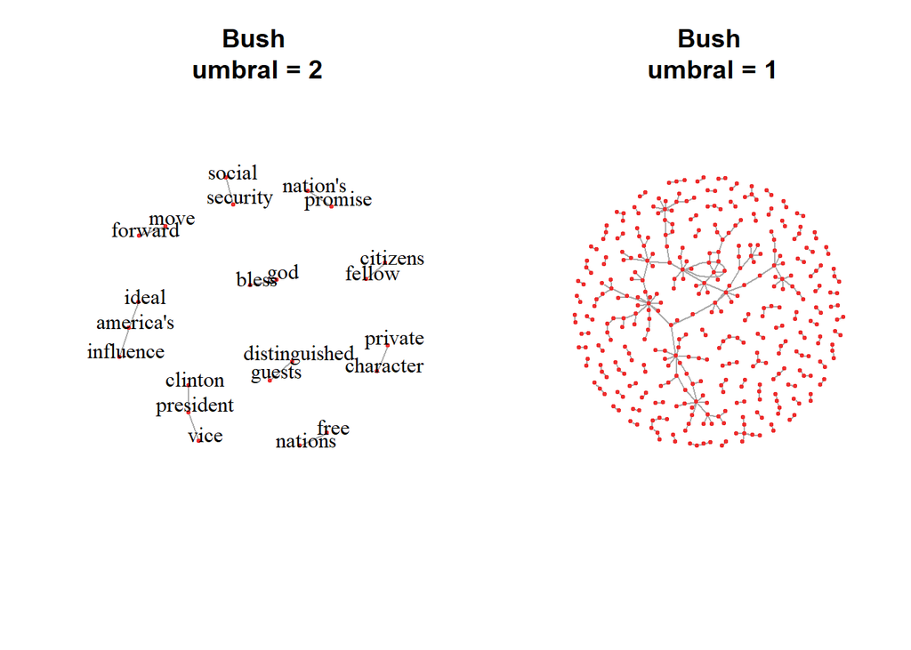

```r
#---------------------------------------------------------------------------------- Bush
# grafo con umbral=2
g_bush1 <- text_bush_bi_counts %>%
  filter(weight > 1) %>%
  graph_from_data_frame(directed = FALSE)

# grafo con umbral=1
g_bush0 <- text_bush_bi_counts %>%
  filter(weight > 0) %>%
  graph_from_data_frame(directed = FALSE)

# grafo inducido por la componente conexa más grande
V(g_bush0)$cluster <- clusters(graph = g_bush0)$membership
Compg_bush <- induced_subgraph(graph = g_bush0, vids = which(V(g_bush0)$cluster == which.max(clusters(graph = g_bush0)$csize)))

# Grafos
par(mfrow=c(1,2))

set.seed(1234)
plot(g_bush1, layout = layout_with_fr, vertex.color = "firebrick2", vertex.frame.color = "firebrick2", vertex.size = 3, vertex.label.color = 'black', vertex.label.cex = 1, vertex.label.dist = 1, main = "Bush\n umbral = 2")

set.seed(123)
plot(g_bush0, layout = layout_with_fr, vertex.color = "firebrick2", vertex.frame.color = "firebrick2", vertex.size = 3, vertex.label = NA, vertex.label.color = 'black', vertex.label.cex = 1, vertex.label.dist = 1, main = "Bush\n umbral = 1")
```

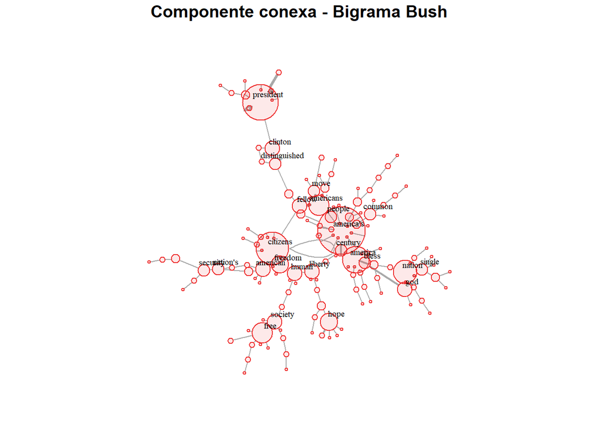

```r
# componente gigante
par(mfrow = c(1,1), mar = c(1,1,2,1), mgp = c(1,1,1))

# tamaño de vertices según la fuerza del mismo, grosor de aristas según la proporción del peso de la misma

#vector de labels para vertices con fuerza mayor que 3
nombres<-ifelse(strength(Compg_bush)>3, names(strength(Compg_bush)), NA)

set.seed(1234)
plot(Compg_bush, layout = layout_with_kk, vertex.color = adjustcolor("firebrick2", 0.1), vertex.frame.color = "firebrick2", vertex.size = 2*strength(Compg_bush), vertex.label=nombres, vertex.label.color = 'black', vertex.label.cex = 0.6, vertex.label.dist = 1, edge.width = 3*E(g_bush0)$weight/max(E(g_bush0)$weight))
title(main = "Componente conexa - Bigrama Bush", outer = T, line = -1)
```

En el grafo de umbral=2 se observan las conexiones entre las palabras con frecuencia mayor o igual a dos, teniendo en cuenta esto, se tienen una mejor idea de los temas principales del discurso, por lo tanto, en el discurso de Bush propondría un progreso enfatizando en la seguridad y libertad de los habitantes estadounidenses. Continuando, al ver la componente gigante del grafo de umbral=1, se evidencia como Bush trata de cierta manera el ideal norteamericano sobre la libertad, esto debido a la relación entre palabras con una fuerza significativa, como lo son american, freedom, liberty y citizens. Además de como Estados Unidos afrontaría el nuevo siglo.

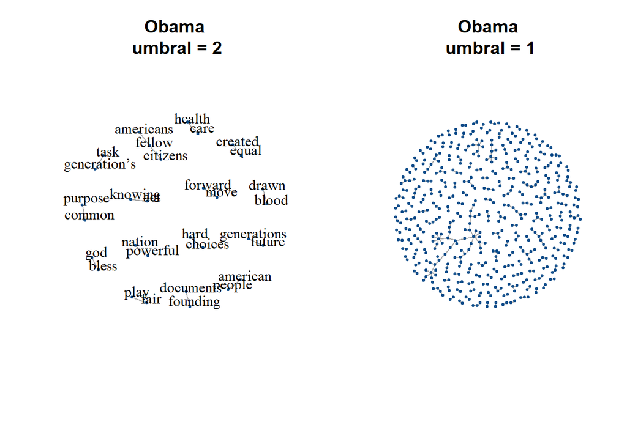

```r
#---------------------------------------------------------------------------------- Obama
# grafo con umbral=2
g_obama1 <- text_obama_bi_counts %>%
  filter(weight > 1) %>%
  graph_from_data_frame(directed = FALSE)

# grafo con umbral=1
g_obama0 <- text_obama_bi_counts %>%
  filter(weight > 0) %>%
  graph_from_data_frame(directed = FALSE)

# grafo inducido por la componente conexa más grande
V(g_obama0)$cluster <- clusters(graph = g_obama0)$membership
Compg_obama <- induced_subgraph(graph = g_obama0, vids = which(V(g_obama0)$cluster == which.max(clusters(graph = g_obama0)$csize)))

# Grafos
par(mfrow=c(1,2))

set.seed(34)
plot(g_obama1, layout = layout_with_fr, vertex.color = "dodgerblue4", vertex.frame.color = "dodgerblue4", vertex.size = 3, vertex.label.color = 'black', vertex.label.cex = 1, vertex.label.dist = 1, main = "Obama\n umbral = 2")

set.seed(123)
plot(g_obama0, layout = layout_with_fr, vertex.color = "dodgerblue4", vertex.frame.color = "dodgerblue4", vertex.size = 3, vertex.label = NA, vertex.label.color = 'black', vertex.label.cex = 1, vertex.label.dist = 1, main = "Obama\n umbral = 1")
```

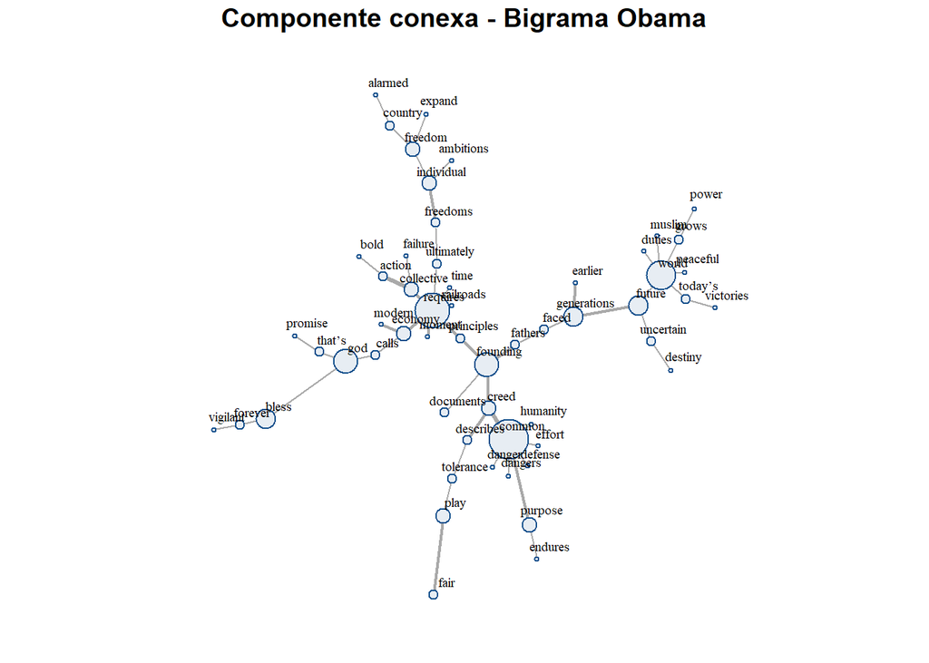

```r
# componente gigante
par(mfrow = c(1,1), mar = c(1,1,2,1), mgp = c(1,1,1))



# tamaño de vertices según la fuerza del mismo, grosor de aristas según la proporción del peso de la misma
set.seed(123)
plot(Compg_obama, layout = layout_with_kk, vertex.color = adjustcolor("dodgerblue4", 0.1), vertex.frame.color = "dodgerblue4", vertex.size = 2*strength(Compg_obama), vertex.label.color = 'black', vertex.label.cex = 0.6, vertex.label.dist = 1, edge.width = 3*E(g_obama0)$weight/max(E(g_obama0)$weight))
title(main = "Componente conexa - Bigrama Obama", outer = T, line = -1)
```

En el discurso de Obama, al centrarnos en el grafo de umbral=2, se puede inferir que Obama habla de como las nuevas generaciones son las encargadas de continuar manteniendo la prosperidad de Estados Unidos, para que sea una nación donde haya igualdad, libertad y bienestar. En cuanto a la componente gigante del grafo de umbral=1, se evidencia por medio de el peso de las aristas temas importantes tales como que las generaciones futuras deberán afrontar las consecuencias presentes, protegiendo los intereses comunes y las libertades individuales y de como las acciones colectivas ayudan al crecimiento del país, además posiblemente habla de la tolerancia que debe haber entre los diferentes credos.

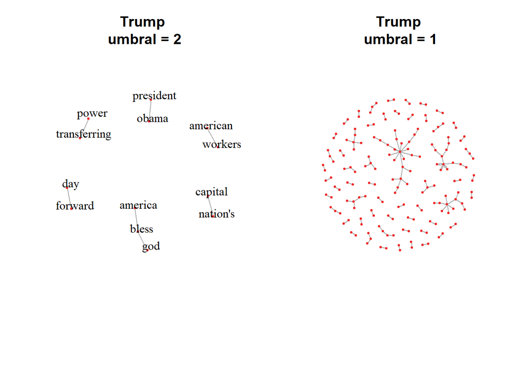

```r
#---------------------------------------------------------------------------------- Trump
# grafo con umbral=2
g_trump1 <- text_trump_bi_counts %>%
  filter(weight > 1) %>%
  graph_from_data_frame(directed = FALSE)

# grafo con umbral=1
g_trump0 <- text_trump_bi_counts %>%
  filter(weight > 0) %>%
  graph_from_data_frame(directed = FALSE)

# grafo inducido por la componente conexa más grande
V(g_trump0)$cluster <- clusters(graph = g_trump0)$membership
Compg_trump <- induced_subgraph(graph = g_trump0, vids = which(V(g_trump0)$cluster == which.max(clusters(graph = g_trump0)$csize)))

#### Grafos
par(mfrow=c(1,2))

set.seed(1234)
plot(g_trump1, layout = layout_with_fr, vertex.color = "firebrick2", vertex.frame.color = "firebrick2", vertex.size = 3, vertex.label.color = 'black', vertex.label.cex = 1, vertex.label.dist = 1, main = "Trump\n umbral = 2")

set.seed(123)
plot(g_trump0, layout = layout_with_fr, vertex.color = "firebrick2", vertex.frame.color = "firebrick2", vertex.size = 3, vertex.label = NA, vertex.label.color = 'black', vertex.label.cex = 1, vertex.label.dist = 1, main = "Trump\n umbral = 1")
```

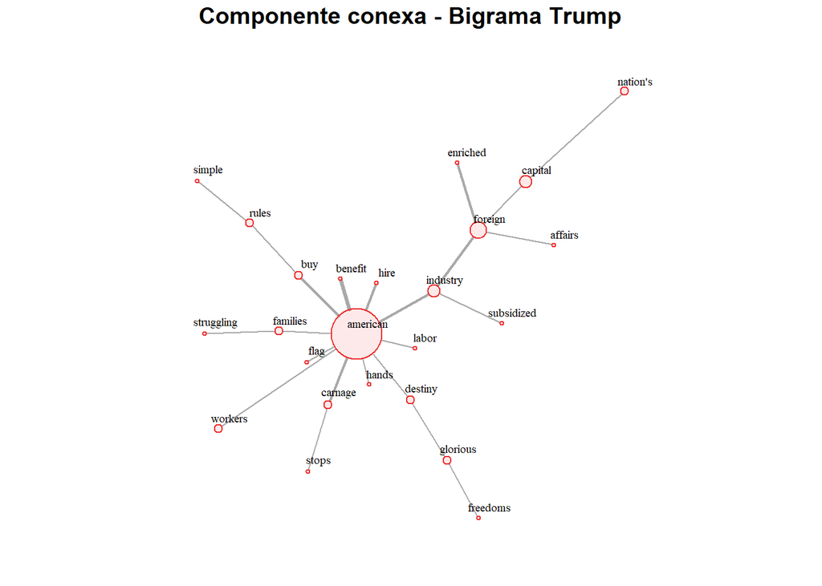

```r
# componente gigante
par(mfrow = c(1,1), mar = c(1,1,2,1), mgp = c(1,1,1))

# tamaño de vertices según la fuerza del mismo, grosor de aristas según la proporción del peso de la misma
set.seed(123)
plot(Compg_trump, layout = layout_with_kk, vertex.color = adjustcolor("firebrick2", 0.1), vertex.frame.color = "firebrick2", vertex.size = 2*strength(Compg_trump), vertex.label.color = 'black', vertex.label.cex = 0.6, vertex.label.dist = 1, edge.width = 3*E(g_trump0)$weight/max(E(g_trump0)$weight))
title(main = "Componente conexa - Bigrama Trump", outer = T, line = -1)
```

En el discurso de Trump, basados en el grafo de umbral=2, se puede llegar a pensar que el tema central es el avance de la nación por medio del trabajo de los estadounidenses, ahondando más en esto se analiza la componente gigante del grafo de umbral=1, la cual respalda lo anteriormente mencionado,esto se evidencia en el grafo al ver como la palabra american se encuentra frecuentemente relacionada, principalmente hablando de beneficios y temas del mundo laboral.

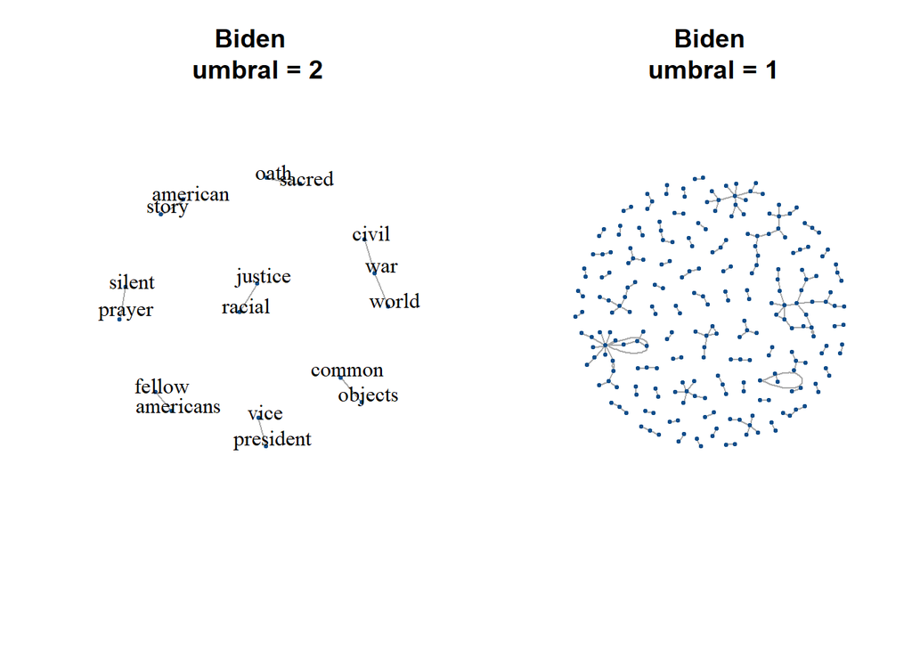

```r
#---------------------------------------------------------------------------------- Biden
# grafo con umbral=2
g_biden1 <- text_biden_bi_counts %>%
  filter(weight > 1) %>%
  graph_from_data_frame(directed = FALSE)

# grafo con umbral=1
g_biden0 <- text_biden_bi_counts %>%
  filter(weight > 0) %>%
  graph_from_data_frame(directed = FALSE)

# grafo inducido por la componente conexa más grande
V(g_biden0)$cluster <- clusters(graph = g_biden0)$membership
Compg_biden <- induced_subgraph(graph = g_biden0, vids = which(V(g_biden0)$cluster == which.max(clusters(graph = g_biden0)$csize)))

# Grafos
par(mfrow=c(1,2))

set.seed(1234)
plot(g_biden1, layout = layout_with_fr, vertex.color = "dodgerblue4", vertex.frame.color = "dodgerblue4", vertex.size = 3, vertex.label.color = 'black', vertex.label.cex = 1, vertex.label.dist = 1, main = "Biden \n umbral = 2")

set.seed(123)
plot(g_biden0, layout = layout_with_fr, vertex.color = "dodgerblue4", vertex.frame.color = "dodgerblue4", vertex.size = 3, vertex.label = NA, vertex.label.color = 'black', vertex.label.cex = 1, vertex.label.dist = 1, main = "Biden\n umbral = 1")
```

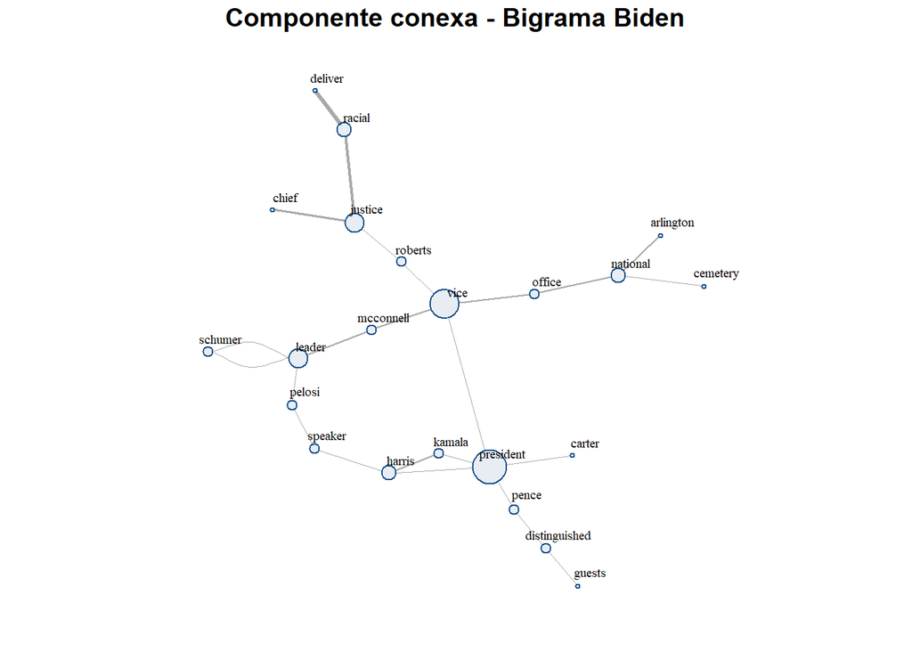

```r
# componente gigante
par(mfrow = c(1,1), mar = c(1,1,2,1), mgp = c(1,1,1))

# tamaño de vertices según la fuerza del mismo, grosor de aristas según la proporción del peso de la misma
set.seed(123)
plot(Compg_biden, layout = layout_with_kk, vertex.color = adjustcolor("dodgerblue4", 0.1), vertex.frame.color = "dodgerblue4", vertex.size = 2*strength(Compg_biden), vertex.label.color = 'black', vertex.label.cex = 0.6, vertex.label.dist = 1, edge.width = 3*E(g_biden0)$weight/max(E(g_biden0)$weight))
title(main = "Componente conexa - Bigrama Biden", outer = T, line = -1)
```

Teniendo un poco más presente el contexto socio-politico bajo el cual Biden fue electo, se evidencia en su discurso la justicia racial, además de distintos problemas bélicos al rededor del mundo. En cuanto a la componente gigante del grafo de umbral=1, se observan principalmente nombres de su gabinete, los cuales se asumen como posibles figuras importantes de su gobierno.

## 8 Skip-gramas

```r
text_bush_skip <- text_bush_st %>%
  unnest_tokens(tbl = ., input = text, output = skipgram, token = "skip_ngrams", n = 2) %>%
  filter(!is.na(skipgram))

text_obama_skip <- text_obama_st %>%
  unnest_tokens(tbl = ., input = text, output = skipgram, token = "skip_ngrams", n = 2) %>%
  filter(!is.na(skipgram))

text_trump_skip <- text_trump_st %>%
  unnest_tokens(tbl = ., input = text, output = skipgram, token = "skip_ngrams", n = 2) %>%
  filter(!is.na(skipgram))

text_biden_skip <- text_biden_st %>%
  unnest_tokens(tbl = ., input = text, output = skipgram, token = "skip_ngrams", n = 2) %>%
  filter(!is.na(skipgram))

dim(text_bush_skip)
```

```
## [1] 10716     2
```

```r
dim(text_obama_skip)
```

```
## [1] 13323     2
```

```r
dim(text_trump_skip)
```

```
## [1] 4305    2
```

```r
dim(text_biden_skip)
```

```
## [1] 6513    2
```

Se remueven los unigramas del análisis

```r
#----------------------------------------------------------------------------- Bush
# contar palabras en cada skip-gram
text_bush_skip$num_words <- text_bush_skip$skipgram %>%
  map_int(.f = ~ wordcount(.x))

head(text_bush_skip, n = 10)
```

```
## # A tibble: 10 x 3
##     line skipgram                num_words
##    <int> <chr>                       <int>
##  1     1 president                       1
##  2     1 president clinton               2
##  3     1 president distinguished         2
##  4     1 clinton                         1
##  5     1 clinton distinguished           2
##  6     1 clinton guests                  2
##  7     1 distinguished                   1
##  8     1 distinguished guests            2
##  9     1 distinguished and               2
## 10     1 guests                          1
```

```r
# remover unigramas
text_bush_skip %<>%
  filter(num_words == 2) %>%
  select(-num_words)

dim(text_bush_skip)
```

```
## [1] 7063    2
```

```r
#----------------------------------------------------------------------------- Obama
# contar palabras en cada skip-gram
text_obama_skip$num_words <- text_obama_skip$skipgram %>%
  map_int(.f = ~ wordcount(.x))

head(text_obama_skip, n = 10)
```

```
## # A tibble: 10 x 3
##     line skipgram        num_words
##    <int> <chr>               <int>
##  1     1 my                      1
##  2     1 my fellow               2
##  3     1 my citizens             2
##  4     1 fellow                  1
##  5     1 fellow citizens         2
##  6     1 fellow i                2
##  7     1 citizens                1
##  8     1 citizens i              2
##  9     1 citizens stand          2
## 10     1 i                       1
```

```r
# remover unigramas
text_obama_skip %<>%
  filter(num_words == 2) %>%
  select(-num_words)

dim(text_obama_skip)
```

```
## [1] 8818    2
```

```r
#----------------------------------------------------------------------------------------- Trump
# contar palabras en cada skip-gram
text_trump_skip$num_words <- text_trump_skip$skipgram %>%
  map_int(.f = ~ wordcount(.x))

head(text_trump_skip, n = 10)
```

```
## # A tibble: 10 x 3
##     line skipgram          num_words
##    <int> <chr>                 <int>
##  1     1 chief                     1
##  2     1 chief justice             2
##  3     1 chief roberts             2
##  4     1 justice                   1
##  5     1 justice roberts           2
##  6     1 justice president         2
##  7     1 roberts                   1
##  8     1 roberts president         2
##  9     1 roberts carter            2
## 10     1 president                 1
```

```r
# remover unigramas
text_trump_skip %<>%
  filter(num_words == 2) %>%
  select(-num_words)

dim(text_trump_skip)
```

```
## [1] 2851    2
```

```r
#----------------------------------------------------------------------------------------- Biden
# contar palabras en cada skip-gram
text_biden_skip$num_words <- text_biden_skip$skipgram %>%
  map_int(.f = ~ wordcount(.x))

head(text_biden_skip, n = 10)
```

```
## # A tibble: 10 x 3
##     line skipgram          num_words
##    <int> <chr>                 <int>
##  1     1 chief                     1
##  2     1 chief justice             2
##  3     1 chief roberts             2
##  4     1 justice                   1
##  5     1 justice roberts           2
##  6     1 justice vice              2
##  7     1 roberts                   1
##  8     1 roberts vice              2
##  9     1 roberts president         2
## 10     1 vice                      1
```

```r
# remover unigramas
text_biden_skip %<>%
  filter(num_words == 2) %>%
  select(-num_words)

dim(text_biden_skip)
```

```
## [1] 4136    2
```

Como se realizó anteriormente se normalizan los tokens

```r
#----------------------------------------------------------------------------------------- Bush
text_bush_skip %>%
  separate(skipgram, c("word1", "word2"), sep = " ") %>%
  filter(!grepl(pattern = '[0-9]', x = word1)) %>%          # se eliminan los números
  filter(!grepl(pattern = '[0-9]', x = word2)) %>%
  filter(!word1 %in% stop_words$word) %>%                   # se eliminan las stop_words
  filter(!word2 %in% stop_words$word) %>%
  filter(!is.na(word1)) %>%
  filter(!is.na(word2)) %>%
  count(word1, word2, sort = TRUE) %>%
  rename(weight = n) -> text_bush_skip_counts              # el peso de cada pareja de palabras (bigrama) es su frecuencia

#----------------------------------------------------------------------------------------- Obama
text_obama_skip %>%
  separate(skipgram, c("word1", "word2"), sep = " ") %>%
  filter(!grepl(pattern = '[0-9]', x = word1)) %>%          # se eliminan los números
  filter(!grepl(pattern = '[0-9]', x = word2)) %>%
  filter(!word1 %in% stop_words$word) %>%                   # se eliminan las stop_words
  filter(!word2 %in% stop_words$word) %>%
  filter(!is.na(word1)) %>%
  filter(!is.na(word2)) %>%
  count(word1, word2, sort = TRUE) %>%
  rename(weight = n) -> text_obama_skip_counts              # el peso de cada pareja de palabras (bigrama) es su frecuencia

#---------------------------------------------------------------------------------------- Trump
text_trump_skip %>%
  separate(skipgram, c("word1", "word2"), sep = " ") %>%
  filter(!grepl(pattern = '[0-9]', x = word1)) %>%          # se eliminan los números
  filter(!grepl(pattern = '[0-9]', x = word2)) %>%
  filter(!word1 %in% stop_words$word) %>%                   # se eliminan las stop_words
  filter(!word2 %in% stop_words$word) %>%
  filter(!is.na(word1)) %>%
  filter(!is.na(word2)) %>%
  count(word1, word2, sort = TRUE) %>%
  rename(weight = n) -> text_trump_skip_counts              # el peso de cada pareja de palabras (bigrama) es su frecuencia


#---------------------------------------------------------------------------------------- Biden
text_biden_skip %>%
  separate(skipgram, c("word1", "word2"), sep = " ") %>%
  filter(!grepl(pattern = '[0-9]', x = word1)) %>%          # se eliminan los números
  filter(!grepl(pattern = '[0-9]', x = word2)) %>%
  filter(!word1 %in% stop_words$word) %>%                   # se eliminan las stop_words
  filter(!word2 %in% stop_words$word) %>%
  filter(!is.na(word1)) %>%
  filter(!is.na(word2)) %>%
  count(word1, word2, sort = TRUE) %>%
  rename(weight = n) -> text_biden_skip_counts              # el peso de cada pareja de palabras (bigrama) es su frecuencia

dim(text_bush_skip_counts)
```

```
## [1] 861   3
```

```r
dim(text_obama_skip_counts)
```

```
## [1] 1025    3
```

```r
dim(text_trump_skip_counts)
```

```
## [1] 306   3
```

```r
dim(text_biden_skip_counts)
```

```
## [1] 438   3
```

```r
head(text_bush_skip_counts, n = 10)
```

```
## # A tibble: 10 x 3
##    word1       word2        weight
##    <chr>       <chr>         <int>
##  1 america's   ideal             3
##  2 fellow      citizens          3
##  3 god         bless             3
##  4 ideal       freedom           3
##  5 president   clinton           3
##  6 america's   influence         2
##  7 angel       rides             2
##  8 declaration independence      2
##  9 depends     private           2
## 10 directs     storm             2
```

```r
head(text_obama_skip_counts, n = 10)
```

```
## # A tibble: 10 x 3
##    word1    word2     weight
##    <chr>    <chr>      <int>
##  1 created  equal          3
##  2 god      bless          3
##  3 act      knowing        2
##  4 american people         2
##  5 bless    united         2
##  6 blood    drawn          2
##  7 build    roads          2
##  8 common   purpose        2
##  9 fair     play           2
## 10 fascism  communism      2
```

```r
head(text_trump_skip_counts, n = 10)
```

```
## # A tibble: 10 x 3
##    word1        word2       weight
##    <chr>        <chr>        <int>
##  1 god          bless            3
##  2 president    president        3
##  3 american     workers          2
##  4 bless        america          2
##  5 day          forward          2
##  6 god          america          2
##  7 nation's     capital          2
##  8 president    obama            2
##  9 transferring power            2
## 10 accept       politicians      1
```

```r
head(text_biden_skip_counts, n = 10)
```

```
## # A tibble: 10 x 3
##    word1     word2     weight
##    <chr>     <chr>      <int>
##  1 fellow    americans      5
##  2 american  story          4
##  3 vice      president      3
##  4 civil     war            2
##  5 common    objects        2
##  6 president harris         2
##  7 racial    justice        2
##  8 sacred    oath           2
##  9 silent    prayer         2
## 10 world     war            2
```

### 8.1 Grafos

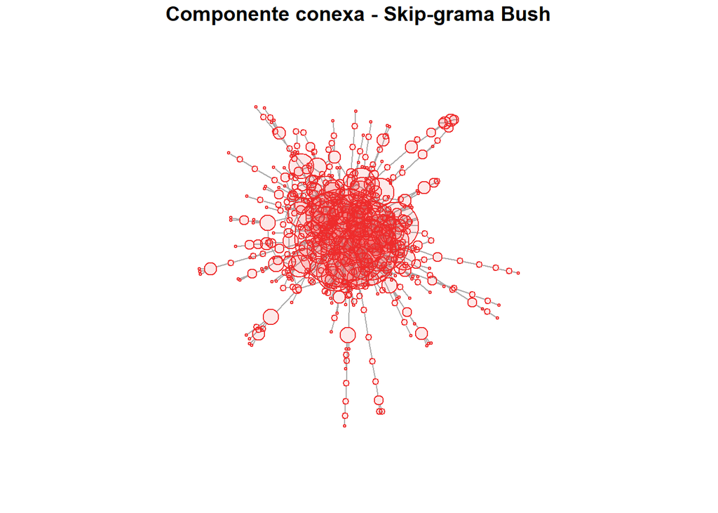

```r
#---------------------------------------------------------------------------------------- Bush
##### definir una red a partir de la frecuencia (weight) de los bigramas
g_bush_sk <- text_bush_skip_counts %>%
  filter(weight > 0) %>%
  graph_from_data_frame(directed = FALSE)

g_bush_sk <- igraph::simplify(g_bush_sk)

# grafo inducido por la componente conexa
V(g_bush_sk)$cluster <- clusters(graph = g_bush_sk)$membership
Compg_bush_sk <- induced_subgraph(graph = g_bush_sk, vids = which(V(g_bush_sk)$cluster == which.max(clusters(graph = g_bush_sk)$csize)))

### Grafos
par(mfrow = c(1,1), mar = c(1,1,2,1), mgp = c(1,1,1))

# tamaño de vertices según la fuerza del mismo
set.seed(123)
plot(Compg_bush_sk, layout = layout_with_fr, vertex.color = adjustcolor("firebrick2", 0.1), vertex.frame.color = "firebrick2", vertex.size = 2*strength(Compg_bush_sk), vertex.label = NA)
title(main = "Componente conexa - Skip-grama Bush", outer = T, line = -1)
```

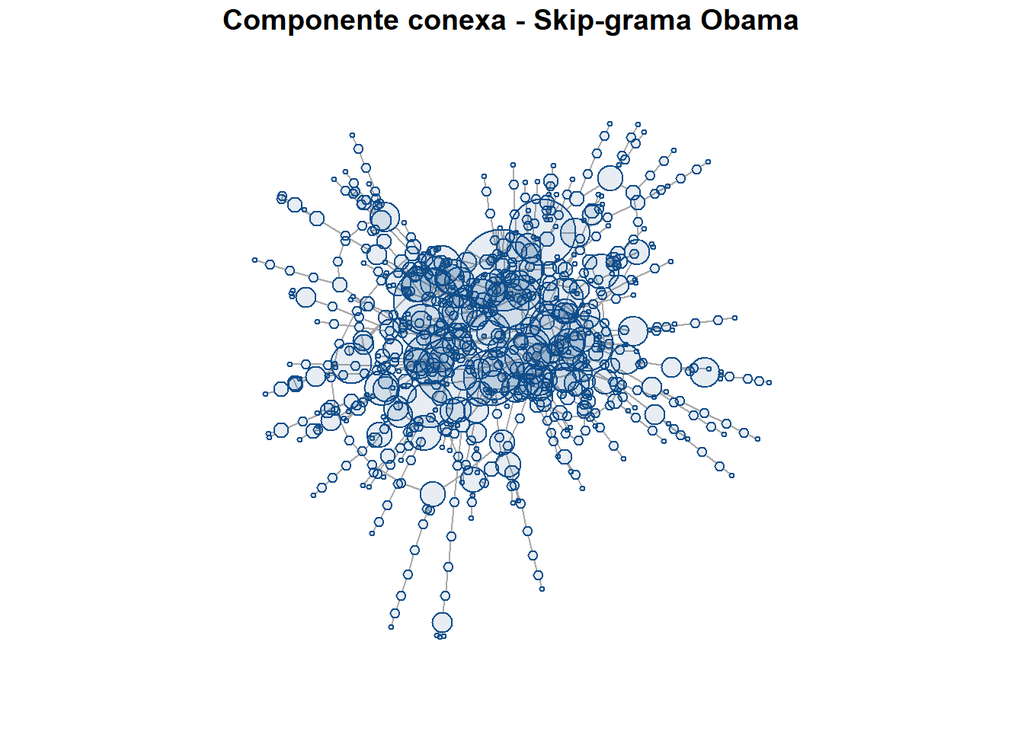

```r
#---------------------------------------------------------------------------------------- Obama
##### definir una red a partir de la frecuencia (weight) de los bigramas
g_obama_sk <- text_obama_skip_counts %>%
  filter(weight > 0) %>%
  graph_from_data_frame(directed = FALSE)

g_obama_sk <- igraph::simplify(g_obama_sk)

# grafo inducido por la componente conexa
V(g_obama_sk)$cluster <- clusters(graph = g_obama_sk)$membership
Compg_obama_sk <- induced_subgraph(graph = g_obama_sk, vids = which(V(g_obama_sk)$cluster == which.max(clusters(graph = g_obama_sk)$csize)))

### Grafos
par(mfrow = c(1,1), mar = c(1,1,2,1), mgp = c(1,1,1))

# tamaño de vertices según la fuerza del mismo
set.seed(123)
plot(Compg_obama_sk, layout = layout_with_fr, vertex.color = adjustcolor("dodgerblue4", 0.1), vertex.frame.color = "dodgerblue4", vertex.size = 2*strength(Compg_obama_sk), vertex.label = NA)
title(main = "Componente conexa - Skip-grama Obama", outer = T, line = -1)
```

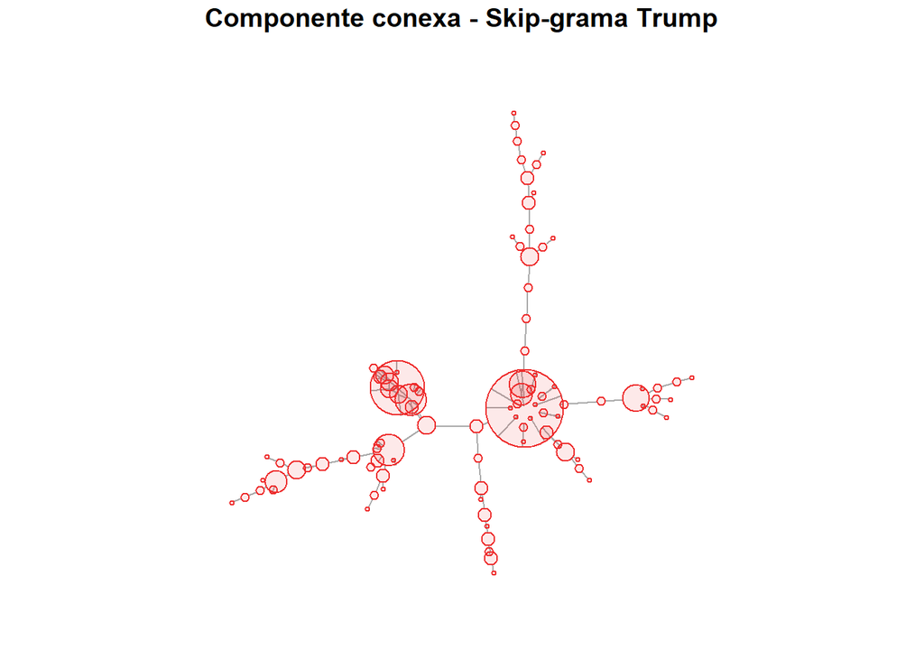

```r
#---------------------------------------------------------------------------------------- Trump
##### definir una red a partir de la frecuencia (weight) de los bigramas
g_trump_sk <- text_trump_skip_counts %>%
  filter(weight > 0) %>%
  graph_from_data_frame(directed = FALSE)

g_trump_sk <- igraph::simplify(g_trump_sk)

# grafo inducido por la componente conexa
V(g_trump_sk)$cluster <- clusters(graph = g_trump_sk)$membership
Compg_trump_sk <- induced_subgraph(graph = g_trump_sk, vids = which(V(g_trump_sk)$cluster == which.max(clusters(graph = g_trump_sk)$csize)))

### Grafos
par(mfrow = c(1,1), mar = c(1,1,2,1), mgp = c(1,1,1))

# tamaño de vertices según la fuerza del mismo
set.seed(123)
plot(Compg_trump_sk, layout = layout_with_fr, vertex.color = adjustcolor("firebrick2", 0.1), vertex.frame.color = "firebrick2", vertex.size = 2*strength(Compg_trump_sk), vertex.label = NA)
title(main = "Componente conexa - Skip-grama Trump", outer = T, line = -1)
```

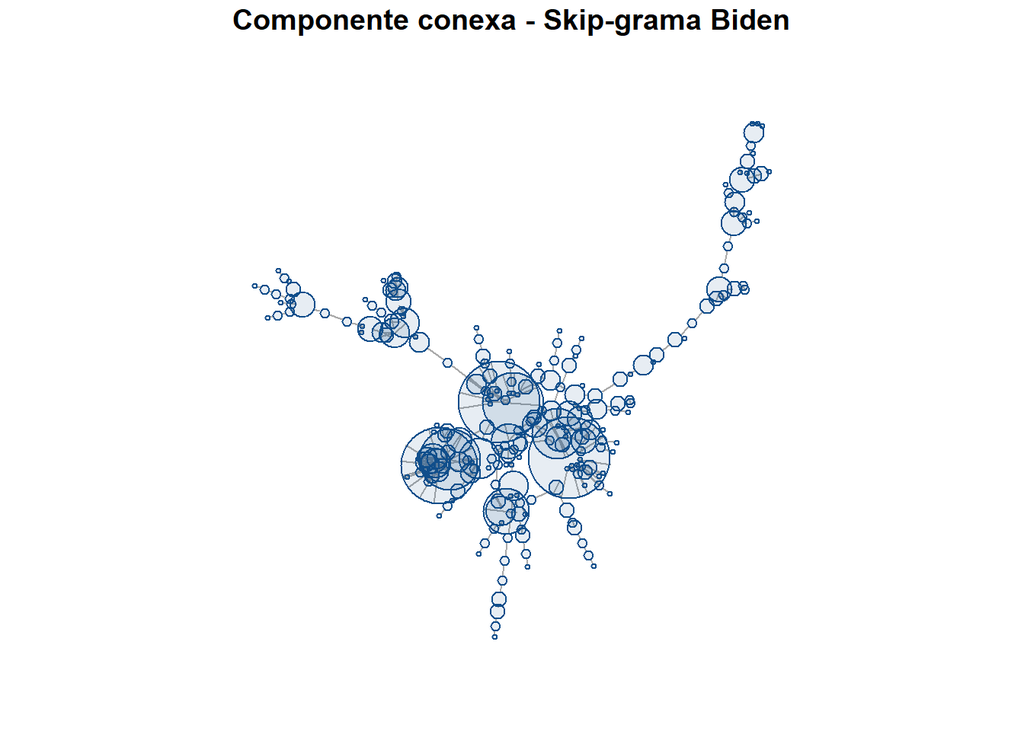

```r
#---------------------------------------------------------------------------------------- Biden
##### definir una red a partir de la frecuencia (weight) de los bigramas
g_biden_sk <- text_biden_skip_counts %>%
  filter(weight > 0) %>%
  graph_from_data_frame(directed = FALSE)

g_biden_sk <- igraph::simplify(g_biden_sk)

# grafo inducido por la componente conexa
V(g_biden_sk)$cluster <- clusters(graph = g_biden_sk)$membership
Compg_biden_sk <- induced_subgraph(graph = g_biden_sk, vids = which(V(g_biden_sk)$cluster == which.max(clusters(graph = g_biden_sk)$csize)))

### Grafos
par(mfrow = c(1,1), mar = c(1,1,2,1), mgp = c(1,1,1))

# tamaño de vertices según la fuerza del mismo
set.seed(123)
plot(Compg_biden_sk, layout = layout_with_fr, vertex.color = adjustcolor("dodgerblue4", 0.1), vertex.frame.color = "dodgerblue4", vertex.size = 2*strength(Compg_biden_sk), vertex.label = NA)
title(main = "Componente conexa - Skip-grama Biden", outer = T, line = -1)
```

Debido a que los anteriores grafos presentan mayor tamaño y complejidad en su visualización, se analizarán sus estadisticas estructurales y su partición por temáticas a continuación.

## 9 Comparación entre discursos

### 9.1 Estadísticas estructurales

```r
estad <- function(grafo, presi){
  dist_geo <- mean_distance(graph = grafo, directed = FALSE)
  grado_prom <- mean(degree(graph = grafo))
  sd_grado <- sd(degree(graph = grafo))
  num_clan <- length(largest.cliques(graph = g_obama_sk)[[1]])
  densidad <- edge_density(grafo)
  asortatividad <- assortativity_degree(graph = grafo, directed= F)
  datos <- rbind(dist_geo, grado_prom, sd_grado, num_clan, densidad, asortatividad)
  colnames(datos) <- presi
  return(data.frame(round(datos, 3)))
}


cbind(estad(Compg_bush_sk, "Bush"),estad(Compg_obama_sk, "Obama"), estad(Compg_trump_sk, "Trump"), estad(Compg_biden_sk, "Biden"))
```

```
##                 Bush  Obama  Trump  Biden
## dist_geo       6.260  8.878  8.090 10.629
## grado_prom     2.678  2.391  2.265  2.496
## sd_grado       2.601  1.744  1.774  1.969
## num_clan       3.000  3.000  3.000  3.000
## densidad       0.005  0.003  0.023  0.010
## asortatividad -0.001 -0.045 -0.203 -0.079
```

### 9.2 Top 10 de los grafos

```r
top <- function(grafo){
  vec <- eigen_centrality(graph = grafo, scale = T)$vector
  vec_ord <- sort(vec, decreasing = T)
  eig_ord <- data.frame("word"=names(vec_ord), "eig"=vec_ord)
  rownames(eig_ord) <- NULL
  return(eig_ord)
}

top(Compg_bush_sk)[1:10,]
```

```
##         word       eig
## 1    freedom 1.0000000
## 2      ideal 0.6260001
## 3   citizens 0.5225101
## 4  america's 0.4909763
## 5    justice 0.4060908
## 6     nation 0.3826374
## 7  president 0.3403891
## 8        god 0.3262508
## 9     fellow 0.3029748
## 10 americans 0.2779534
```

```r
top(Compg_obama_sk)[1:10,]
```

```
##          word       eig
## 1         god 1.0000000
## 2       bless 0.7295984
## 3  generation 0.4274861
## 4        care 0.3668740
## 5   americans 0.3617122
## 6     country 0.3515820
## 7        oath 0.3266818
## 8      nation 0.3011287
## 9      united 0.2990589
## 10       gift 0.2875754
```

```r
top(Compg_trump_sk)[1:10,]
```

```
##          word       eig
## 1     america 1.0000000
## 2         god 0.7684709
## 3       bless 0.7525665
## 4      united 0.3495909
## 5    citizens 0.1894160
## 6        safe 0.1893829
## 7      spirit 0.1805180
## 8      bigger 0.1803044
## 9  solidarity 0.1803044
## 10      start 0.1803044
```

```r
top(Compg_biden_sk)[1:10,]
```

```
##         word       eig
## 1  president 1.0000000
## 2       vice 0.9186815
## 3     harris 0.5768444
## 4     kamala 0.3761064
## 5  mcconnell 0.3671650
## 6    roberts 0.3398495
## 7      pence 0.3337670
## 8     leader 0.3304569
## 9     office 0.3198847
## 10   speaker 0.3195700
```

### 9.3 Agrupamiento

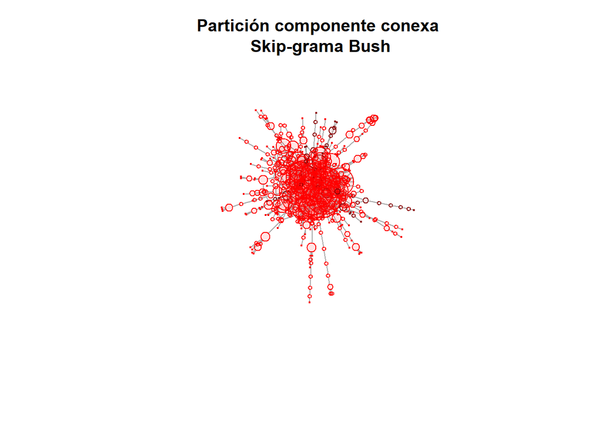

```r
Agrupamiento <- function(grafo, presi, col_osc, col_cl){
  lista <- NULL

  # partición del grafo
  lista[[1]] <- agrup <- cluster_fast_greedy(grafo)

  # se asigna un color diferente a los vertices del grupo más grande
  V(grafo)$color <- ifelse(agrup$membership==order(sizes(agrup), decreasing = T)[1], col_osc, col_cl)

  # Grafo
  set.seed(123)
  lista[[2]] <-plot(grafo, layout = layout_with_fr, vertex.color = adjustcolor(V(grafo)$color, 0.1), vertex.frame.color = V(grafo)$color, vertex.size = 2*strength(grafo), vertex.label = NA, main = paste0("Partición componente conexa\n Skip-grama ", presi))

  return(lista)
}

Agrup_bush <-Agrupamiento(Compg_bush_sk, "Bush", "red4", "red")
```

```r
Agrup_obama <-Agrupamiento(Compg_obama_sk, "Obama", "dodgerblue4", "deepskyblue")
```

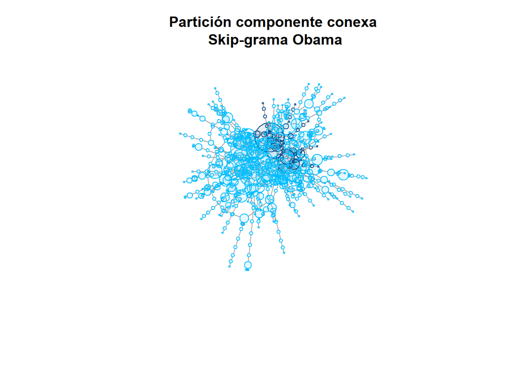

```r
Agrup_trump <-Agrupamiento(Compg_trump_sk, "Trump", "red4", "red")
```

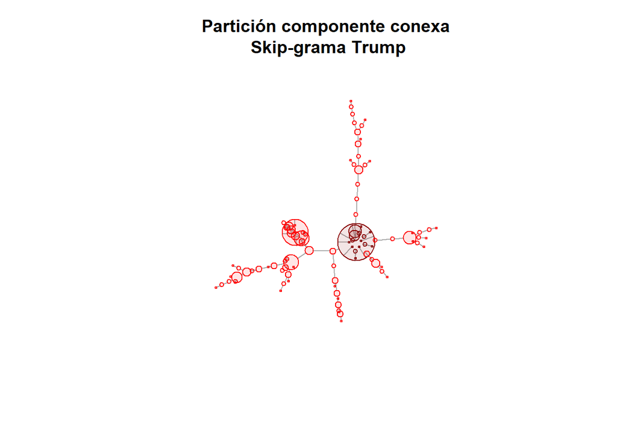

```r
Agrup_biden <-Agrupamiento(Compg_biden_sk, "Biden", "dodgerblue4", "deepskyblue")
```

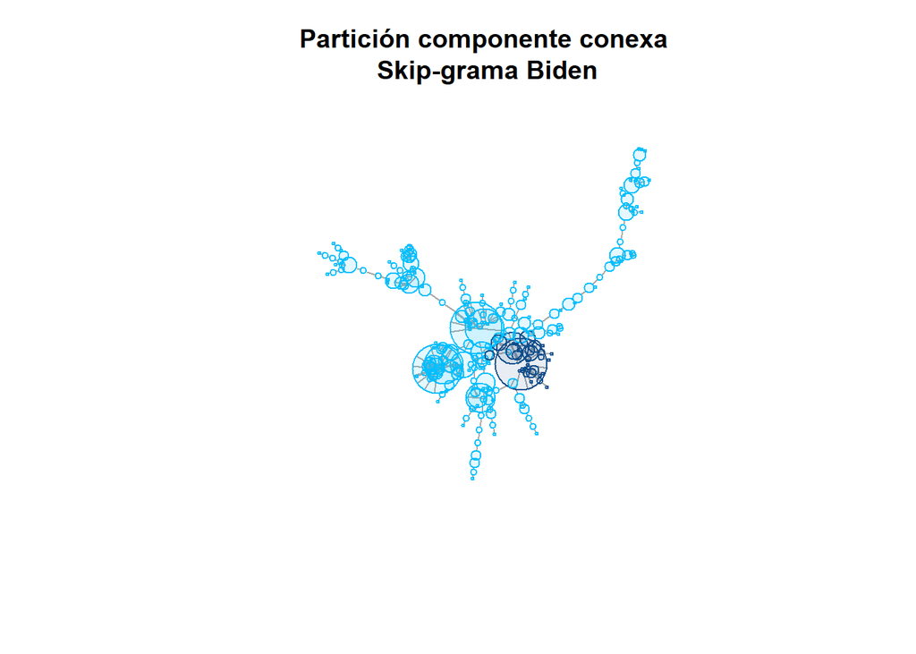

Debido a que los anteriores grafos presentan gran tamaño y complejidad en su visualización, se analizarán sus estadisticas de centralidad a continuación.

```r
med_agrup <- function(part, grafo, presi){
  lista <- NULL

  # número de grupos
  num_grup <- length(part)

  # tamaño grupo más grande
  tam_grup_mayor <- sort(sizes(part), decreasing = T)[1]

  # tamaño grupo más pequeño
  tam_grup_menor <- sort(sizes(part), decreasing = F)[1]

  lista[[1]] <- data.frame(rbind(num_grup, tam_grup_mayor, tam_grup_menor))
  colnames(lista[[1]]) <- presi

  lista[[2]] <- top(grafo)%>%
    inner_join(data.frame("word"=part$names, "grupo"=part$membership), by=c("word"="word"))%>%
    arrange(desc(eig)) %>%
    filter(grupo==order(sizes(part), decreasing = T)[1])

  return(lista)
}

MedAgrup_bush <- med_agrup(Agrup_bush[[1]], Compg_bush_sk, "Bush")
MedAgrup_obama <- med_agrup(Agrup_obama[[1]], Compg_obama_sk, "Obama")
MedAgrup_trump <- med_agrup(Agrup_trump[[1]], Compg_trump_sk, "Trump")
MedAgrup_biden <- med_agrup(Agrup_biden[[1]], Compg_biden_sk, "Biden")

cbind(MedAgrup_bush[[1]],MedAgrup_obama[[1]], MedAgrup_trump[[1]], MedAgrup_biden[[1]] )
```

```
##                Bush Obama Trump Biden
## num_grup         23    26     9    14
## tam_grup_mayor   42    56    16    34
## tam_grup_menor    7     6     6     5
```

```r
MedAgrup_bush[[2]][1:5,]
```

```
##         word        eig grupo
## 1       call 0.16360609     6
## 2    advance 0.14552402     6
## 3 compassion 0.11749049     6
## 4    courage 0.05435061     6
## 5   civility 0.04928676     6
```

```r
MedAgrup_obama[[2]][1:5,]
```

```
##         word        eig grupo
## 1     nation 0.30112870     3
## 2   powerful 0.14082369     3
## 3       hard 0.09456150     3
## 4 prosperous 0.09084483     3
## 5      earth 0.08769553     3
```

```r
MedAgrup_trump[[2]][1:5,]
```

```
##      word       eig grupo
## 1 america 1.0000000     2
## 2     god 0.7684709     2
## 3   bless 0.7525665     2
## 4  united 0.3495909     2
## 5  bigger 0.1803044     2
```

```r
MedAgrup_biden[[2]][1:5,]
```

```
##        word         eig grupo
## 1     truth 0.040790386     2
## 2      hope 0.015010071     2
## 3    defend 0.007920430     2
## 4 democracy 0.005253769     2
## 5   america 0.003639319     2
```

Como se mencionó anteriormente, al ser los grafos de los discrsos de Bush y Obama generados por la unión de dos discursos, su número de grupos o de temáticas es mucho mayor a los grafos generados por los discursos de Trump y Biden. Posteriormente se analizan las palabras más importante en la temática principal de cada discurso.

Para el discurso de Bush, se podría afirmar que el tema principal es un llamado a los estadounidenses a tener mejor cultura ciudadana. Para el discurso de Obama, se podría afirmar que el tema principal es mantener viva la grandeza y el poder norteamericano. Para el discurso de Trump, se podría afirmar que el tema principal va en corriente con su principal eslogan de campaña, el cual fue “make America great again”. Finalmente para el discurso de Biden, se podría afirmar que el tema principal es proteger la democracia en Estados Unidos y sus bondades como lo son la esperanza y la verdad.